# Assignment 1A — Building & Fine-Tuning a Domain-Specific LLM

## Step 3 — Model Loading & Architecture Inspection (2 marks)

Loads `openai-community/gpt2-medium` in bfloat16 with gradient checkpointing (as the brief says for T4), shows the parameter count and architecture, checks the prediction head against the vocabulary size, and saves baseline generations from the untrained model. Steps 4, 5B and B3 are compared against these.

```python
# ---------------------------------------------------------------------------
# Load the base model.
#
# bfloat16 + gradient checkpointing is what the brief specifies for a T4. Note that
# gradient checkpointing only takes effect during training (it trades recomputation
# for activation memory); it is inert under torch.no_grad(), so it does not affect
# the baseline generations below.
# ---------------------------------------------------------------------------
import torch
from transformers import AutoModelForCausalLM

DEVICE = "cuda" if torch.cuda.is_available() else "cpu"
DTYPE = torch.bfloat16

model = AutoModelForCausalLM.from_pretrained(MODEL_ID, dtype=DTYPE)
model.to(DEVICE)
model.eval()
model.gradient_checkpointing_enable()

print(f"Model    : {MODEL_ID}")
print(f"Device   : {DEVICE}")
print(f"Dtype    : {DTYPE}")
print(f"Grad ckpt: {model.is_gradient_checkpointing}")

if DEVICE == "cuda":
    print(f"GPU      : {torch.cuda.get_device_name(0)}")
    print(f"Weights  : {torch.cuda.memory_allocated() / 1024**3:.2f} GB on device")
    # A T4 is Turing (sm_75) and has NO native bfloat16 units - bf16 works, but the
    # hardware emulates it. This is worth knowing before Step 4: the brief prescribes
    # bf16 for T4, so we follow it, but fp16 is the natively supported alternative if
    # training turns out to be slow.
    capability = torch.cuda.get_device_capability(0)
    native_bf16 = capability[0] >= 8
    bf16_supported = torch.cuda.is_bf16_supported()
    print(f"BF16 native hardware: {native_bf16}")
    print(f"BF16 runtime support (may be emulated): {bf16_supported}")
else:
    native_bf16 = None
    bf16_supported = None
    print("  WARNING: running on CPU - Step 4 training will be impractically slow.")
```

```
Model    : openai-community/gpt2-medium
Device   : cuda
Dtype    : torch.bfloat16
Grad ckpt: True
GPU      : Tesla T4
Weights  : 0.66 GB on device
BF16 native hardware: False
BF16 runtime support (may be emulated): True
```

```python
# ---------------------------------------------------------------------------
# Architecture audit: parameter count, layer geometry, and the prediction-head check.
# ---------------------------------------------------------------------------
total_params = sum(p.numel() for p in model.parameters())
trainable_params = sum(p.numel() for p in model.parameters() if p.requires_grad)

n_layers = model.config.num_hidden_layers
n_heads = model.config.num_attention_heads
hidden = model.config.hidden_size
head_dim = hidden // n_heads

# The prediction head is fetched via get_output_embeddings() rather than by attribute.
# get_output_embeddings() is the portable accessor every causal-LM implementation
# provides, whatever the head is called (`lm_head` in GPT-2, tied to the input embeddings).
head = model.get_output_embeddings()
head_attr = next((n for n, m in model.named_modules() if m is head), "unknown")
vocab_size = model.config.vocab_size
head_matches_vocab = head.out_features == vocab_size

print_table(
    ("property", "value"),
    [
        ("total parameters", f"{total_params:,}"),
        ("trainable parameters", f"{trainable_params:,}"),
        ("decoder layers", f"{n_layers}"),
        ("attention heads", f"{n_heads}"),
        ("hidden size", f"{hidden:,}"),
        ("head dimension (hidden / heads)", f"{head_dim}"),
        ("vocabulary size", f"{vocab_size:,}"),
        ("prediction head attribute", head_attr),
        ("prediction head out_features", f"{head.out_features:,}"),
        ("head == vocab size", "YES" if head_matches_vocab else "NO - MISMATCH"),
        ("weights tied to embeddings", str(bool(model.config.tie_word_embeddings))),
    ],
    title=f"STEP 3 - ARCHITECTURE AUDIT: {MODEL_ID}",
)

# This is the check the brief asks for, and it is the same property Step 2's validation
# enforced from the data side: if the head and the vocabulary disagree, some token IDs
# in the packed corpus have no corresponding output logit and training cannot be correct.
assert head_matches_vocab, (
    f"prediction head outputs {head.out_features} logits but the vocabulary has "
    f"{vocab_size} tokens - tokenizer and model do not match"
)
assert head.out_features == len(tok), "prediction head does not match the loaded tokenizer"
print("\nPASS  prediction head, model config and tokenizer all agree on vocabulary size.")
```

```
=============================================
STEP 3 - ARCHITECTURE AUDIT: openai-community/gpt2-medium
=============================================
property                                value
---------------------------------------------
total parameters                  354,823,168
trainable parameters              354,823,168
decoder layers                             24
attention heads                            16
hidden size                             1,024
head dimension (hidden / heads)            64
vocabulary size                        50,257
prediction head attribute             lm_head
prediction head out_features           50,257
head == vocab size                        YES
weights tied to embeddings               True
=============================================

PASS  prediction head, model config and tokenizer all agree on vocabulary size.
```

```python
# ---------------------------------------------------------------------------
# Baseline inference on the UNTRAINED model.
#
# These prompts are locked here and reused verbatim in Steps 4, 5B and B3. Comparing
# stages only means something if the prompt and the decoding settings are identical
# every time, so both live in one place and later steps call this same function.
#
# Decoding is greedy (do_sample=False): sampling would make each run differ, and a
# before/after comparison would then be measuring randomness as much as training.
# ---------------------------------------------------------------------------

# Domain prompts - deliberately mid-sentence, so the model must continue in domain
# register rather than answer a question. That is what CPT should improve.
DOMAIN_PROMPTS = [
    "The first-line pharmacological treatment for type 2 diabetes is",
    "In adults with type 2 diabetes, the recommended HbA1c target is",
    "Metformin should be used with caution in patients who have",
]

# General prompts - the brief's own examples, unrelated to the domain. Step 5B uses
# these to detect catastrophic forgetting.
GENERAL_PROMPTS = [
    "The capital of France is",
    "Water boils at",
    "The speed of light is approximately",
]

MAX_NEW_TOKENS = 60


def generate_completions(model, prompts, tag):
    """Greedy-decode each prompt and return {prompt: completion}.

    Kept as a function so Steps 4, 5B and B3 reproduce these settings exactly rather
    than re-specifying them and quietly drifting.
    """
    model.eval()
    out = {}
    for p in prompts:
        ids = tok(p, return_tensors="pt").to(model.device)
        with torch.no_grad():
            gen = model.generate(
                **ids,
                max_new_tokens=MAX_NEW_TOKENS,
                do_sample=False,          # greedy: reproducible across stages
                use_cache=True,
                pad_token_id=tok.pad_token_id if tok.pad_token_id is not None else eos_id,
            )
        out[p] = tok.decode(gen[0], skip_special_tokens=True)
        print(f"  [{tag}] {p}")
    return out


print("Generating baseline completions (untrained model) ...\n")
baseline = {
    "model_id": MODEL_ID,
    "stage": "base (before CPT)",
    "dtype": str(DTYPE),
    "device": DEVICE,
    "max_new_tokens": MAX_NEW_TOKENS,
    "decoding": "greedy (do_sample=False)",
    "domain": generate_completions(model, DOMAIN_PROMPTS, "domain"),
    "general": generate_completions(model, GENERAL_PROMPTS, "general"),
}

# Use the same outputs directory created during Step 1. Defining this here keeps
# Step 3 runnable after a fresh Colab restart and avoids an undefined path.
OUTPUTS_DIR = STATS_PATH.parent
OUTPUTS_DIR.mkdir(parents=True, exist_ok=True)
BASELINE_PATH = OUTPUTS_DIR / "baseline_generations.json"
BASELINE_PATH.write_text(json.dumps(baseline, indent=2), encoding="utf-8")

# 6 outputs, not 3: the general prompts are generated now, while the base model is
# already in memory, because Step 5B needs base-model answers to them and reloading
# the model later just to get them would waste GPU time.
assert len(baseline["domain"]) == 3 and len(baseline["general"]) == 3
print(f"\nSaved 6 baseline generations (3 domain + 3 general) to {BASELINE_PATH}")

for section in ("domain", "general"):
    print(f"\n{'=' * 78}\nBASELINE - {section.upper()} PROMPTS (untrained model)\n{'=' * 78}")
    for prompt, completion in baseline[section].items():
        continuation = completion[len(prompt):].strip()
        print(f"\n  PROMPT     {prompt}")
        print(f"  CONTINUES  {continuation}")
```

```
Generating baseline completions (untrained model) ...

  [domain] The first-line pharmacological treatment for type 2 diabetes is
  [domain] In adults with type 2 diabetes, the recommended HbA1c target is
  [domain] Metformin should be used with caution in patients who have
  [general] The capital of France is
  [general] Water boils at
  [general] The speed of light is approximately

Saved 6 baseline generations (3 domain + 3 general) to outputs/baseline_generations.json

==============================================================================
BASELINE - DOMAIN PROMPTS (untrained model)
==============================================================================

  PROMPT     The first-line pharmacological treatment for type 2 diabetes is
  CONTINUES  metformin, which is a combination of insulin and metformin. Metformin is a hormone that is produced by the pancreas. It is a hormone that is produced by the pancreas that is used to control blood sugar levels. Metformin is a hormone that is produced

  PROMPT     In adults with type 2 diabetes, the recommended HbA1c target is
  CONTINUES  6.5% (95% CI, 4.0%-7.0%).

The recommended HbA1c target for adults with type 2 diabetes is 6.5% (95% CI, 4.0%-7.0%).

The recommended HbA1c

  PROMPT     Metformin should be used with caution in patients who have
  CONTINUES  a history of diabetes mellitus, hypertension, or hyperlipidemia.

The use of metformin in patients with diabetes mellitus should be limited to the first 6 months of treatment.

Metformin should be used with caution in patients with a history of hyperlipidemia

==============================================================================
BASELINE - GENERAL PROMPTS (untrained model)
==============================================================================

  PROMPT     The capital of France is
  CONTINUES  Paris, and the capital of France is Paris.

The capital of France is Paris, and the capital of France is Paris.

The capital of France is Paris, and the capital of France is Paris.

The capital of France is Paris, and the capital of France is Paris

  PROMPT     Water boils at
  CONTINUES  a temperature of about 1,000 degrees Fahrenheit.

"The water is very hot, and it's very hot," said Dr. David L. Karp, a professor of geology at the University of California, Santa Cruz. "It's very hot, and it's very hot."

  PROMPT     The speed of light is approximately
  CONTINUES  186,000 miles per hour.

The speed of light is approximately 186,000 miles per hour.

The speed of light is approximately 186,000 miles per hour.

The speed of light is approximately 186,000 miles per hour.

The speed of light is approximately
```

```python
# ---------------------------------------------------------------------------
# Inference - Step 3 (numbers come from the cells above).
# ---------------------------------------------------------------------------
from IPython.display import Markdown, display

_domain_lines = "\n".join(
    f"- **{p}** -> {c[len(p):].strip()}" for p, c in baseline["domain"].items()
)
_general_lines = "\n".join(
    f"- **{p}** -> {c[len(p):].strip()}" for p, c in baseline["general"].items()
)

_text = f"""**Inference — Step 3**

**Parameters.** {trainable_params:,} trainable out of {total_params:,} total, so every parameter is trainable. This is full-parameter CPT, unlike the adapter training in Part B. The model has {n_layers} layers, {n_heads} attention heads and hidden size {hidden:,} (head dimension {hidden:,} / {n_heads} = {head_dim}). The count is about {total_params / 1e6:.0f}M; the brief's table lists GPT-2-Medium as 345M, which is just the usual label for the same model.

**Prediction head.** The head is `{head_attr}` (checked through `get_output_embeddings()`). It gives {head.out_features:,} outputs for a vocabulary of {vocab_size:,}: {"they match" if head_matches_vocab else "MISMATCH"}. So every token ID has an output and the loss is well defined.

**Baseline generations (untrained model, greedy decoding).**

Domain prompts:
{_domain_lines}

General prompts:
{_general_lines}

The base model only continues the text; it does not answer like an assistant. It was trained on general web text, so its medical wording is less precise, and this gap is what CPT in Step 4 tries to close. We use greedy decoding so that the base, CPT and adapter outputs differ only because of training and not because of random sampling.

**bfloat16 on a T4.** Running on **{DEVICE}** in **{DTYPE}**. The brief asks for bf16 on T4. PyTorch reports bf16 support as **{bf16_supported}**, but the T4 has no native bf16 hardware (native: **{native_bf16}**), so it is emulated and slower. fp16 would be the fallback if training were too slow.
"""
display(Markdown(_text))
```

**Inference — Step 3**

**Parameters.** 354,823,168 trainable out of 354,823,168 total, so every parameter is trainable. This is full-parameter CPT, unlike the adapter training in Part B. The model has 24 layers, 16 attention heads and hidden size 1,024 (head dimension 1,024 / 16 = 64). The count is about 355M; the brief's table lists GPT-2-Medium as 345M, which is just the usual label for the same model.

**Prediction head.** The head is `lm_head` (checked through `get_output_embeddings()`). It gives 50,257 outputs for a vocabulary of 50,257: they match. So every token ID has an output and the loss is well defined.

**Baseline generations (untrained model, greedy decoding).**

Domain prompts:

- **The first-line pharmacological treatment for type 2 diabetes is** -> metformin, which is a combination of insulin and metformin. Metformin is a hormone that is produced by the pancreas. It is a hormone that is produced by the pancreas that is used to control blood sugar levels. Metformin is a hormone that is produced

- **In adults with type 2 diabetes, the recommended HbA1c target is** -> 6.5% (95% CI, 4.0%-7.0%).

The recommended HbA1c target for adults with type 2 diabetes is 6.5% (95% CI, 4.0%-7.0%).

The recommended HbA1c

- **Metformin should be used with caution in patients who have** -> a history of diabetes mellitus, hypertension, or hyperlipidemia.

The use of metformin in patients with diabetes mellitus should be limited to the first 6 months of treatment.

Metformin should be used with caution in patients with a history of hyperlipidemia

General prompts:

- **The capital of France is** -> Paris, and the capital of France is Paris.

The capital of France is Paris, and the capital of France is Paris.

The capital of France is Paris, and the capital of France is Paris.

The capital of France is Paris, and the capital of France is Paris

- **Water boils at** -> a temperature of about 1,000 degrees Fahrenheit.

"The water is very hot, and it's very hot," said Dr. David L. Karp, a professor of geology at the University of California, Santa Cruz. "It's very hot, and it's very hot."

- **The speed of light is approximately** -> 186,000 miles per hour.

The speed of light is approximately 186,000 miles per hour.

The speed of light is approximately 186,000 miles per hour.

The speed of light is approximately 186,000 miles per hour.

The speed of light is approximately

The base model only continues the text; it does not answer like an assistant. It was trained on general web text, so its medical wording is less precise, and this gap is what CPT in Step 4 tries to close. We use greedy decoding so that the base, CPT and adapter outputs differ only because of training and not because of random sampling.

**bfloat16 on a T4.** Running on **cuda** in **torch.bfloat16**. The brief asks for bf16 on T4. PyTorch reports bf16 support as **True**, but the T4 has no native bf16 hardware (native: **False**), so it is emulated and slower. fp16 would be the fallback if training were too slow.

## Step 4 — CPT Training Loop & Loss Analysis (2 marks)

**Required by the brief:** a PyTorch `Dataset` over the packed data, training hyperparameters, a custom `TrainerCallback` that records the loss at every logging step, a loss-vs-step plot (loss should fall from the pretrained start of about 2–4, with the plateau marked), and the final model and tokenizer saved to persistent storage.

**Recipe (T4, 14.6 GB).** `gpt2-medium` has about 355M parameters, so full-parameter CPT fits on the T4 without freezing layers: FP32 weights, gradients and AdamW states take about 6 GB, and gradient checkpointing keeps activation memory small. We use BF16 autocast (the brief's precision for T4), batch 4 × accumulation 2 = 8 sequences of 1,024 tokens per step, learning rate 2e-5 with cosine decay and 10% warmup, for 3 epochs.

```python
# ---------------------------------------------------------------------------
# Step 4 configuration: hyperparameters and where checkpoints live.
# ---------------------------------------------------------------------------
import math
import shutil

CPT_BATCH_SIZE = 4           # four 1,024-token sequences per forward pass fit the T4
CPT_GRAD_ACCUM = 2           # effective batch of 8 sequences = 8,192 tokens per step
CPT_LR = 2e-5                # gentle: CPT should adapt the model, not overwrite it
CPT_EPOCHS = 3               # a few passes; many repeats over a small corpus cause forgetting
CPT_WARMUP_FRACTION = 0.10   # warmup avoids early loss spikes
CPT_MAX_GRAD_NORM = 1.0
CPT_SAVE_EVERY = 40          # optimizer steps between resumable checkpoints

CPT_CKPT = PERSIST / "cpt_ckpt"          # final model + tokenizer, read by Step 5 and B2
CPT_RUN_DIR = PERSIST / "cpt_run"        # resumable checkpoints during training
CPT_SUMMARY_PATH = CPT_CKPT / "training_summary.json"   # written last = save completed
CPT_LOSS_LOG = "loss_log.json"

print(f"Checkpoint       : {CPT_CKPT.resolve()}")
print(f"Resumable run dir: {CPT_RUN_DIR.resolve()}")
```

```
Checkpoint       : /content/persistent/cpt_ckpt
Resumable run dir: /content/persistent/cpt_run
```

```python
# ---------------------------------------------------------------------------
# Wrap the packed training split in a PyTorch Dataset.
#
# Only the TRAIN split is loaded here. packed_eval.parquet is reserved for Step 5A's
# perplexity, and keeping it out of Step 4 entirely is what makes that number honest.
# ---------------------------------------------------------------------------
import numpy as np
from torch.utils.data import Dataset


class PackedCPTDataset(Dataset):
    """Serves Step 2's packed sequences for causal-LM training.

    Each item returns the same token IDs as both input_ids and labels. The model shifts
    the labels by one position internally, so they are passed UNshifted: shifting them
    here as well would train it to predict two tokens ahead.

    Every sequence is exactly CONTEXT tokens with no padding, so the attention mask is
    all ones and no label needs masking to -100.
    """

    def __init__(self, parquet_path):
        frame = pd.read_parquet(parquet_path)
        self.sequences = [
            torch.as_tensor(np.asarray(ids, dtype=np.int64)) for ids in frame["input_ids"]
        ]

    def __len__(self):
        return len(self.sequences)

    def __getitem__(self, idx):
        ids = self.sequences[idx]
        return {
            "input_ids": ids,
            "attention_mask": torch.ones_like(ids),
            "labels": ids.clone(),
        }


train_ds = PackedCPTDataset(TRAIN_PATH)

# Same checks as Step 2's validation, repeated on what was READ BACK from disk: this is
# the data the Trainer will actually see, and a bad ID here becomes an opaque CUDA error.
lengths = {len(s) for s in train_ds.sequences}
max_id = max(int(s.max()) for s in train_ds.sequences)
assert lengths == {CONTEXT}, f"expected every sequence to be {CONTEXT} tokens, got {lengths}"
assert max_id < len(tok), f"token id {max_id} is outside the {len(tok):,}-token vocabulary"
if "train_chunks" in globals():
    assert len(train_ds) == len(train_chunks), "parquet on disk differs from Step 2's split"

sample = train_ds[0]
assert torch.equal(sample["input_ids"], sample["labels"])

print(f"Training sequences : {len(train_ds):,} x {CONTEXT:,} tokens "
      f"= {len(train_ds) * CONTEXT:,} tokens per epoch")
print(f"Largest token id   : {max_id:,} (vocabulary {len(tok):,})")
print(f"First sequence     : {tok.decode(sample['input_ids'][:40])!r} ...")
```

```
Training sequences : 607 x 1,024 tokens = 621,568 tokens per epoch
Largest token id   : 50,256 (vocabulary 50,257)
First sequence     : '<|endoftext|>HSE COMMUNITY NUTRITION & DIETETIC SERVICE\nCARE GUIDELINES for the MANAGEMENT of\nTYPE 2 DIABETES\n\nDevelop' ...
```

```python
# ---------------------------------------------------------------------------
# Custom TrainerCallback: capture the training loss at every logging step.
#
# With logging_steps=1 the Trainer logs after every optimizer step, so this records one
# loss per optimizer step (a couple of hundred points for the full run), enough to see where it plateaus.
#
# The history is also written to JSON after every entry. On Colab the kernel's memory
# is lost on a disconnect, so without this a resumed run would plot only the steps after
# the reconnect, and the starting loss the brief asks about would be gone.
# ---------------------------------------------------------------------------
from transformers import TrainerCallback


class LossLoggerCallback(TrainerCallback):
    def __init__(self, log_path, resume_step: int = 0):
        self.log_path = Path(log_path)
        self.history: list[dict] = []
        if resume_step and self.log_path.exists():
            prior = json.loads(self.log_path.read_text(encoding="utf-8"))
            # Steps after the last checkpoint are trained again on resume, so their old
            # entries are dropped; keeping them would plot those steps twice.
            self.history = [h for h in prior if h["step"] <= resume_step]
            print(f"Loss history restored: {len(self.history)} steps up to step {resume_step}")

    def on_log(self, args, state, control, logs=None, **kwargs):
        # The Trainer's end-of-run summary logs "train_loss" (the run average), not
        # "loss", so it is skipped here and only per-step losses are recorded.
        if not logs or "loss" not in logs:
            return
        entry = {
            "step": int(state.global_step),
            "epoch": round(float(state.epoch or 0.0), 4),
            "loss": float(logs["loss"]),
            "learning_rate": float(logs["learning_rate"]) if "learning_rate" in logs else None,
            "grad_norm": float(logs["grad_norm"]) if logs.get("grad_norm") is not None else None,
        }
        self.history.append(entry)
        self.log_path.parent.mkdir(parents=True, exist_ok=True)
        self.log_path.write_text(json.dumps(self.history, indent=1), encoding="utf-8")
        grad = f"{entry['grad_norm']:.3f}" if entry["grad_norm"] is not None else "-"
        print(f"  step {entry['step']:>4}  epoch {entry['epoch']:.2f}  "
              f"loss {entry['loss']:.4f}  lr {entry['learning_rate'] or 0:.2e}  grad_norm {grad}")
```

```python
# ---------------------------------------------------------------------------
# Build a fresh pretrained model for training (always reloaded, never Step 3's object).
# ---------------------------------------------------------------------------
import gc


def free_gpu():
    gc.collect()
    if torch.cuda.is_available():
        torch.cuda.empty_cache()


def build_cpt_model():
    """Load gpt2-medium with FP32 master weights; bf16 autocast happens inside the Trainer."""
    m = AutoModelForCausalLM.from_pretrained(MODEL_ID, dtype=torch.float32)
    m.config.use_cache = False               # conflicts with gradient checkpointing
    return m.to(DEVICE)
```

```python
# ---------------------------------------------------------------------------
# Train (resume if interrupted, skip if cpt_ckpt/ is already complete).
# ---------------------------------------------------------------------------
import time

from transformers import Trainer, TrainingArguments
from transformers.trainer_utils import get_last_checkpoint

steps_per_epoch = math.ceil(len(train_ds) / (CPT_BATCH_SIZE * CPT_GRAD_ACCUM))
total_steps = steps_per_epoch * CPT_EPOCHS
warmup_steps = max(1, round(total_steps * CPT_WARMUP_FRACTION))

# Step 3's model holds ~3 GB of GPU memory the T4 cannot spare; Step 5 reloads the base.
if "model" in globals():
    del model
for _stale in ("cpt_model", "trainer"):
    globals().pop(_stale, None)
free_gpu()
import gc; gc.collect()

if CPT_SUMMARY_PATH.exists():
    cpt_run = json.loads(CPT_SUMMARY_PATH.read_text(encoding="utf-8"))["run"]
    loss_history = json.loads((CPT_CKPT / CPT_LOSS_LOG).read_text(encoding="utf-8"))
    cpt_model = AutoModelForCausalLM.from_pretrained(CPT_CKPT, dtype=torch.bfloat16).to(DEVICE)
    print(f"cpt_ckpt/ is already complete ({cpt_run['global_step']} steps) - reloaded, not retrained.")
else:
    CPT_RUN_DIR.mkdir(parents=True, exist_ok=True)
    last_ckpt = get_last_checkpoint(str(CPT_RUN_DIR))
    # A checkpoint interrupted mid-save has no trainer_state.json (written last): ignore it.
    if last_ckpt and not (Path(last_ckpt) / "trainer_state.json").exists():
        print(f"Ignoring incomplete checkpoint {last_ckpt}")
        last_ckpt = None
    resume_step = int(Path(last_ckpt).name.split("-")[-1]) if last_ckpt else 0

    cpt_model = build_cpt_model()
    total_params = sum(p.numel() for p in cpt_model.parameters())
    trainable_params = sum(p.numel() for p in cpt_model.parameters() if p.requires_grad)
    print(f"Run              : {'resume from step ' + str(resume_step) if last_ckpt else 'fresh start'}")
    print(f"Optimizer steps  : {total_steps} ({steps_per_epoch} per epoch, {warmup_steps} warmup)")
    print(f"Parameters       : {trainable_params:,} trainable of {total_params:,}")

    args = TrainingArguments(
        output_dir=str(CPT_RUN_DIR),
        per_device_train_batch_size=CPT_BATCH_SIZE,
        gradient_accumulation_steps=CPT_GRAD_ACCUM,
        num_train_epochs=CPT_EPOCHS,
        learning_rate=CPT_LR,
        lr_scheduler_type="cosine",
        warmup_steps=warmup_steps,
        weight_decay=0.0,
        max_grad_norm=CPT_MAX_GRAD_NORM,
        optim="adamw_torch",              # standard AdamW: FP32 states fit easily for a 355M model
        bf16=True,
        gradient_checkpointing=True,
        gradient_checkpointing_kwargs={"use_reentrant": False},
        logging_steps=1,
        logging_first_step=True,
        save_strategy="steps",
        save_steps=CPT_SAVE_EVERY,
        save_total_limit=1,
        report_to="none",
        seed=SEED,
        data_seed=SEED,
        dataloader_num_workers=0,
        remove_unused_columns=False,
        use_cpu=DEVICE == "cpu",
    )

    loss_cb = LossLoggerCallback(CPT_RUN_DIR / CPT_LOSS_LOG, resume_step=resume_step)
    trainer = Trainer(model=cpt_model, args=args, train_dataset=train_ds, callbacks=[loss_cb])

    if torch.cuda.is_available():
        torch.cuda.reset_peak_memory_stats()
    t0 = time.time()
    trainer.train(resume_from_checkpoint=last_ckpt)
    train_seconds = time.time() - t0
    loss_history = loss_cb.history

    peak_gb = torch.cuda.max_memory_allocated() / 1024**3 if torch.cuda.is_available() else None
    cpt_run = {
        "optimizer": "adamw_torch",
        "precision": "FP32 master weights with bf16 autocast",
        "batch_size": CPT_BATCH_SIZE,
        "grad_accum": CPT_GRAD_ACCUM,
        "effective_batch_tokens": CPT_BATCH_SIZE * CPT_GRAD_ACCUM * CONTEXT,
        "learning_rate": CPT_LR,
        "scheduler": "cosine",
        "warmup_steps": warmup_steps,
        "epochs": CPT_EPOCHS,
        "steps_per_epoch": steps_per_epoch,
        "global_step": int(trainer.state.global_step),
        "train_sequences": len(train_ds),
        "total_params": total_params,
        "trainable_params": trainable_params,
        "peak_gpu_memory_gb": round(peak_gb, 2) if peak_gb is not None else None,
        "gpu_total_memory_gb": round(torch.cuda.get_device_properties(0).total_memory / 1024**3, 2)
                               if torch.cuda.is_available() else None,
        "train_minutes_this_session": round(train_seconds / 60, 1),
    }
    print(f"\nTrained in {train_seconds / 60:.1f} min this session"
          + (f"; peak GPU memory {peak_gb:.2f} GB" if peak_gb is not None else ""))

# --- starting-loss check (the brief's tip) ----------------------------------
# ln(vocab) is the loss of a uniform guess: ~10.8 for GPT-2's 50,257 tokens. A first loss near
# it means the model initialised randomly.
first_loss = loss_history[0]["loss"]
print(f"\nFirst logged loss: {first_loss:.3f}  (pretrained expectation 2-4; "
      f"random init ~ ln({len(tok):,}) = {math.log(len(tok)):.2f})")
if first_loss > 6:
    raise RuntimeError(
        f"Starting loss {first_loss:.2f} is far above 2-4 - the pretrained weights "
        "probably did not load. Check Step 3's loading."
    )
```

```
Run              : fresh start
Optimizer steps  : 228 (76 per epoch, 23 warmup)
Parameters       : 354,823,168 trainable of 354,823,168
```

```
[transformers] `loss_type=None` was set in the config but it is unrecognized. Using the default loss: `ForCausalLMLoss`.
```

[228/228 1:11:26, Epoch 3/3]

| Step | Training Loss |
| --- | --- |
| 1 | 2.979021 |
| 2 | 2.803533 |
| 3 | 2.934036 |
| 4 | 3.004228 |
| 5 | 2.928644 |
| 6 | 2.984507 |
| 7 | 2.824987 |
| 8 | 2.992566 |
| 9 | 2.801912 |
| 10 | 2.957332 |
| 11 | 2.761464 |
| 12 | 2.618016 |
| 13 | 2.807648 |
| 14 | 2.702439 |
| 15 | 2.778035 |
| 16 | 2.810472 |
| 17 | 2.763091 |
| 18 | 2.608329 |
| 19 | 2.801700 |
| 20 | 2.785034 |
| 21 | 2.881879 |
| 22 | 3.024522 |
| 23 | 2.700021 |
| 24 | 2.673299 |
| 25 | 2.841727 |
| 26 | 2.760214 |
| 27 | 2.678713 |
| 28 | 2.930577 |
| 29 | 2.625350 |
| 30 | 2.777662 |

[output cut: 198 more lines]

```
  step    1  epoch 0.01  loss 2.9790  lr 0.00e+00  grad_norm 4.367
  step    2  epoch 0.03  loss 2.8035  lr 8.70e-07  grad_norm 3.800
  step    3  epoch 0.04  loss 2.9340  lr 1.74e-06  grad_norm 4.304
  step    4  epoch 0.05  loss 3.0042  lr 2.61e-06  grad_norm 3.738
  step    5  epoch 0.07  loss 2.9286  lr 3.48e-06  grad_norm 4.575
  step    6  epoch 0.08  loss 2.9845  lr 4.35e-06  grad_norm 3.688
  step    7  epoch 0.09  loss 2.8250  lr 5.22e-06  grad_norm 3.656
  step    8  epoch 0.11  loss 2.9926  lr 6.09e-06  grad_norm 4.515
  step    9  epoch 0.12  loss 2.8019  lr 6.96e-06  grad_norm 3.361
  step   10  epoch 0.13  loss 2.9573  lr 7.83e-06  grad_norm 4.221
  step   11  epoch 0.14  loss 2.7615  lr 8.70e-06  grad_norm 3.852
  step   12  epoch 0.16  loss 2.6180  lr 9.57e-06  grad_norm 4.702
  step   13  epoch 0.17  loss 2.8076  lr 1.04e-05  grad_norm 3.161
  step   14  epoch 0.18  loss 2.7024  lr 1.13e-05  grad_norm 3.368
  step   15  epoch 0.20  loss 2.7780  lr 1.22e-05  grad_norm 3.652
  step   16  epoch 0.21  loss 2.8105  lr 1.30e-05  grad_norm 2.824
  step   17  epoch 0.22  loss 2.7631  lr 1.39e-05  grad_norm 2.903
  step   18  epoch 0.24  loss 2.6083  lr 1.48e-05  grad_norm 3.077
  step   19  epoch 0.25  loss 2.8017  lr 1.57e-05  grad_norm 3.487
  step   20  epoch 0.26  loss 2.7850  lr 1.65e-05  grad_norm 2.812
  step   21  epoch 0.28  loss 2.8819  lr 1.74e-05  grad_norm 2.880
  step   22  epoch 0.29  loss 3.0245  lr 1.83e-05  grad_norm 3.523
  step   23  epoch 0.30  loss 2.7000  lr 1.91e-05  grad_norm 3.243
  step   24  epoch 0.32  loss 2.6733  lr 2.00e-05  grad_norm 2.903
  step   25  epoch 0.33  loss 2.8417  lr 2.00e-05  grad_norm 3.239
  step   26  epoch 0.34  loss 2.7602  lr 2.00e-05  grad_norm 3.961
  step   27  epoch 0.36  loss 2.6787  lr 2.00e-05  grad_norm 3.846
  step   28  epoch 0.37  loss 2.9306  lr 2.00e-05  grad_norm 2.966
  step   29  epoch 0.38  loss 2.6253  lr 2.00e-05  grad_norm 2.854
  step   30  epoch 0.39  loss 2.7777  lr 2.00e-05  grad_norm 2.827
  step   31  epoch 0.41  loss 2.8126  lr 1.99e-05  grad_norm 3.003
  step   32  epoch 0.42  loss 2.9573  lr 1.99e-05  grad_norm 3.547
  step   33  epoch 0.43  loss 2.5841  lr 1.99e-05  grad_norm 2.765
  step   34  epoch 0.45  loss 2.6863  lr 1.99e-05  grad_norm 3.218
  step   35  epoch 0.46  loss 2.5330  lr 1.99e-05  grad_norm 2.816
  step   36  epoch 0.47  loss 2.4389  lr 1.98e-05  grad_norm 2.574
  step   37  epoch 0.49  loss 2.7114  lr 1.98e-05  grad_norm 3.203
  step   38  epoch 0.50  loss 2.6911  lr 1.98e-05  grad_norm 3.260
  step   39  epoch 0.51  loss 2.7660  lr 1.97e-05  grad_norm 3.316
  step   40  epoch 0.53  loss 2.7764  lr 1.97e-05  grad_norm 2.585
```

```
  step   41  epoch 0.54  loss 2.6658  lr 1.97e-05  grad_norm 2.939
  step   42  epoch 0.55  loss 2.6524  lr 1.96e-05  grad_norm 2.635
  step   43  epoch 0.57  loss 2.5801  lr 1.96e-05  grad_norm 2.750
  step   44  epoch 0.58  loss 2.6397  lr 1.95e-05  grad_norm 3.024
  step   45  epoch 0.59  loss 2.8486  lr 1.95e-05  grad_norm 3.053
  step   46  epoch 0.61  loss 2.5543  lr 1.94e-05  grad_norm 2.613
  step   47  epoch 0.62  loss 2.4180  lr 1.94e-05  grad_norm 2.536
  step   48  epoch 0.63  loss 2.5419  lr 1.93e-05  grad_norm 2.514
  step   49  epoch 0.64  loss 2.6874  lr 1.93e-05  grad_norm 2.808
  step   50  epoch 0.66  loss 2.7958  lr 1.92e-05  grad_norm 2.603
  step   51  epoch 0.67  loss 2.7400  lr 1.92e-05  grad_norm 2.888
  step   52  epoch 0.68  loss 2.9025  lr 1.91e-05  grad_norm 2.926
  step   53  epoch 0.70  loss 2.7435  lr 1.90e-05  grad_norm 2.776
  step   54  epoch 0.71  loss 2.6399  lr 1.90e-05  grad_norm 2.531
  step   55  epoch 0.72  loss 2.8517  lr 1.89e-05  grad_norm 2.646
  step   56  epoch 0.74  loss 2.6244  lr 1.88e-05  grad_norm 2.575
  step   57  epoch 0.75  loss 2.7505  lr 1.87e-05  grad_norm 2.553
  step   58  epoch 0.76  loss 2.6027  lr 1.87e-05  grad_norm 2.706
  step   59  epoch 0.78  loss 2.6985  lr 1.86e-05  grad_norm 2.900
  step   60  epoch 0.79  loss 2.6692  lr 1.85e-05  grad_norm 2.593
  step   61  epoch 0.80  loss 2.5867  lr 1.84e-05  grad_norm 2.539
  step   62  epoch 0.82  loss 2.6235  lr 1.84e-05  grad_norm 2.941
  step   63  epoch 0.83  loss 2.6109  lr 1.83e-05  grad_norm 2.815
  step   64  epoch 0.84  loss 2.4546  lr 1.82e-05  grad_norm 2.906
  step   65  epoch 0.86  loss 2.6034  lr 1.81e-05  grad_norm 2.565
  step   66  epoch 0.87  loss 2.4771  lr 1.80e-05  grad_norm 2.551
  step   67  epoch 0.88  loss 2.4928  lr 1.79e-05  grad_norm 2.998
  step   68  epoch 0.89  loss 2.5336  lr 1.78e-05  grad_norm 2.566
  step   69  epoch 0.91  loss 2.4714  lr 1.77e-05  grad_norm 2.450
  step   70  epoch 0.92  loss 2.8616  lr 1.76e-05  grad_norm 2.709
  step   71  epoch 0.93  loss 2.6469  lr 1.75e-05  grad_norm 2.840
  step   72  epoch 0.95  loss 2.7435  lr 1.74e-05  grad_norm 2.933
  step   73  epoch 0.96  loss 2.6633  lr 1.73e-05  grad_norm 3.002
  step   74  epoch 0.97  loss 2.5824  lr 1.72e-05  grad_norm 2.759
  step   75  epoch 0.99  loss 2.6627  lr 1.71e-05  grad_norm 2.805
  step   76  epoch 1.00  loss 2.8471  lr 1.70e-05  grad_norm 2.944
  step   77  epoch 1.01  loss 2.3985  lr 1.69e-05  grad_norm 2.497
  step   78  epoch 1.03  loss 2.5162  lr 1.68e-05  grad_norm 2.613
  step   79  epoch 1.04  loss 2.5007  lr 1.67e-05  grad_norm 2.603
  step   80  epoch 1.05  loss 2.4789  lr 1.65e-05  grad_norm 2.506
```

```
  step   81  epoch 1.07  loss 2.7175  lr 1.64e-05  grad_norm 2.526
  step   82  epoch 1.08  loss 2.5393  lr 1.63e-05  grad_norm 2.540
  step   83  epoch 1.09  loss 2.3949  lr 1.62e-05  grad_norm 2.496
  step   84  epoch 1.11  loss 2.7085  lr 1.61e-05  grad_norm 2.589
  step   85  epoch 1.12  loss 2.5873  lr 1.59e-05  grad_norm 2.620
  step   86  epoch 1.13  loss 2.4622  lr 1.58e-05  grad_norm 2.357
  step   87  epoch 1.14  loss 2.4914  lr 1.57e-05  grad_norm 2.990
  step   88  epoch 1.16  loss 2.4265  lr 1.56e-05  grad_norm 2.868
  step   89  epoch 1.17  loss 2.5476  lr 1.54e-05  grad_norm 2.680
  step   90  epoch 1.18  loss 2.4493  lr 1.53e-05  grad_norm 3.144
  step   91  epoch 1.20  loss 2.5431  lr 1.52e-05  grad_norm 2.668
  step   92  epoch 1.21  loss 2.6193  lr 1.50e-05  grad_norm 2.788
  step   93  epoch 1.22  loss 2.7231  lr 1.49e-05  grad_norm 3.063
  step   94  epoch 1.24  loss 2.6019  lr 1.48e-05  grad_norm 3.404
  step   95  epoch 1.25  loss 2.4518  lr 1.46e-05  grad_norm 3.428
  step   96  epoch 1.26  loss 2.6346  lr 1.45e-05  grad_norm 2.733
  step   97  epoch 1.28  loss 2.5232  lr 1.44e-05  grad_norm 2.702
  step   98  epoch 1.29  loss 2.4829  lr 1.42e-05  grad_norm 2.571
  step   99  epoch 1.30  loss 2.6484  lr 1.41e-05  grad_norm 2.668
  step  100  epoch 1.32  loss 2.3807  lr 1.40e-05  grad_norm 2.494
  step  101  epoch 1.33  loss 2.5761  lr 1.38e-05  grad_norm 2.658
  step  102  epoch 1.34  loss 2.6022  lr 1.37e-05  grad_norm 2.733
  step  103  epoch 1.36  loss 2.7649  lr 1.35e-05  grad_norm 2.968
  step  104  epoch 1.37  loss 2.4538  lr 1.34e-05  grad_norm 3.324
  step  105  epoch 1.38  loss 2.4304  lr 1.32e-05  grad_norm 2.600
  step  106  epoch 1.39  loss 2.6499  lr 1.31e-05  grad_norm 3.086
  step  107  epoch 1.41  loss 2.7924  lr 1.29e-05  grad_norm 2.906
  step  108  epoch 1.42  loss 2.5528  lr 1.28e-05  grad_norm 2.859
  step  109  epoch 1.43  loss 2.5700  lr 1.26e-05  grad_norm 3.058
  step  110  epoch 1.45  loss 2.6281  lr 1.25e-05  grad_norm 2.938
  step  111  epoch 1.46  loss 2.3195  lr 1.24e-05  grad_norm 3.135
  step  112  epoch 1.47  loss 2.4870  lr 1.22e-05  grad_norm 2.948
  step  113  epoch 1.49  loss 2.2362  lr 1.21e-05  grad_norm 3.012
  step  114  epoch 1.50  loss 2.4393  lr 1.19e-05  grad_norm 2.800
  step  115  epoch 1.51  loss 2.4643  lr 1.18e-05  grad_norm 2.550
  step  116  epoch 1.53  loss 2.6053  lr 1.16e-05  grad_norm 2.795
  step  117  epoch 1.54  loss 2.5397  lr 1.15e-05  grad_norm 3.112
  step  118  epoch 1.55  loss 2.2568  lr 1.13e-05  grad_norm 2.914
  step  119  epoch 1.57  loss 2.3705  lr 1.11e-05  grad_norm 2.911
  step  120  epoch 1.58  loss 2.5505  lr 1.10e-05  grad_norm 3.646
```

```
  step  121  epoch 1.59  loss 2.7688  lr 1.08e-05  grad_norm 3.310
  step  122  epoch 1.61  loss 2.7057  lr 1.07e-05  grad_norm 2.897
  step  123  epoch 1.62  loss 2.4236  lr 1.05e-05  grad_norm 2.768
  step  124  epoch 1.63  loss 2.4490  lr 1.04e-05  grad_norm 2.810
  step  125  epoch 1.64  loss 2.6044  lr 1.02e-05  grad_norm 2.963
  step  126  epoch 1.66  loss 2.5329  lr 1.01e-05  grad_norm 2.555
  step  127  epoch 1.67  loss 2.4172  lr 9.92e-06  grad_norm 2.590
  step  128  epoch 1.68  loss 2.6673  lr 9.77e-06  grad_norm 2.999
  step  129  epoch 1.70  loss 2.6098  lr 9.62e-06  grad_norm 3.062
  step  130  epoch 1.71  loss 2.3881  lr 9.46e-06  grad_norm 2.753
  step  131  epoch 1.72  loss 2.5863  lr 9.31e-06  grad_norm 2.857
  step  132  epoch 1.74  loss 2.6617  lr 9.16e-06  grad_norm 3.083
  step  133  epoch 1.75  loss 2.6895  lr 9.01e-06  grad_norm 2.864
  step  134  epoch 1.76  loss 2.6118  lr 8.85e-06  grad_norm 2.858
  step  135  epoch 1.78  loss 2.7160  lr 8.70e-06  grad_norm 2.996
  step  136  epoch 1.79  loss 2.6268  lr 8.55e-06  grad_norm 2.993
  step  137  epoch 1.80  loss 2.5464  lr 8.40e-06  grad_norm 2.829
  step  138  epoch 1.82  loss 2.6993  lr 8.25e-06  grad_norm 2.992
  step  139  epoch 1.83  loss 2.2983  lr 8.10e-06  grad_norm 2.833
  step  140  epoch 1.84  loss 2.4701  lr 7.95e-06  grad_norm 2.759
  step  141  epoch 1.86  loss 2.6048  lr 7.80e-06  grad_norm 3.062
  step  142  epoch 1.87  loss 2.5623  lr 7.65e-06  grad_norm 2.793
  step  143  epoch 1.88  loss 2.4258  lr 7.50e-06  grad_norm 3.091
  step  144  epoch 1.89  loss 2.5881  lr 7.35e-06  grad_norm 3.053
  step  145  epoch 1.91  loss 2.5007  lr 7.20e-06  grad_norm 3.204
  step  146  epoch 1.92  loss 2.3089  lr 7.06e-06  grad_norm 2.767
  step  147  epoch 1.93  loss 2.3927  lr 6.91e-06  grad_norm 2.736
  step  148  epoch 1.95  loss 2.5391  lr 6.76e-06  grad_norm 2.612
  step  149  epoch 1.96  loss 2.7254  lr 6.62e-06  grad_norm 2.810
  step  150  epoch 1.97  loss 2.5185  lr 6.48e-06  grad_norm 3.008
  step  151  epoch 1.99  loss 2.7365  lr 6.33e-06  grad_norm 2.702
  step  152  epoch 2.00  loss 2.5721  lr 6.19e-06  grad_norm 3.048
  step  153  epoch 2.01  loss 2.4168  lr 6.05e-06  grad_norm 3.159
  step  154  epoch 2.03  loss 2.6411  lr 5.91e-06  grad_norm 3.184
  step  155  epoch 2.04  loss 2.3918  lr 5.77e-06  grad_norm 2.657
  step  156  epoch 2.05  loss 2.5001  lr 5.63e-06  grad_norm 2.908
  step  157  epoch 2.07  loss 2.4701  lr 5.49e-06  grad_norm 2.974
  step  158  epoch 2.08  loss 2.4425  lr 5.36e-06  grad_norm 3.395
  step  159  epoch 2.09  loss 2.3470  lr 5.22e-06  grad_norm 2.884
  step  160  epoch 2.11  loss 2.2983  lr 5.09e-06  grad_norm 2.722
```

```
  step  161  epoch 2.12  loss 2.4645  lr 4.96e-06  grad_norm 2.883
  step  162  epoch 2.13  loss 2.3875  lr 4.82e-06  grad_norm 3.107
  step  163  epoch 2.14  loss 2.6260  lr 4.69e-06  grad_norm 3.204
  step  164  epoch 2.16  loss 2.6975  lr 4.56e-06  grad_norm 3.197
  step  165  epoch 2.17  loss 2.4267  lr 4.44e-06  grad_norm 2.760
  step  166  epoch 2.18  loss 2.7195  lr 4.31e-06  grad_norm 2.949
  step  167  epoch 2.20  loss 2.4628  lr 4.18e-06  grad_norm 2.895
  step  168  epoch 2.21  loss 2.7400  lr 4.06e-06  grad_norm 2.814
  step  169  epoch 2.22  loss 2.7958  lr 3.94e-06  grad_norm 3.150
  step  170  epoch 2.24  loss 2.4651  lr 3.82e-06  grad_norm 3.082
  step  171  epoch 2.25  loss 2.5624  lr 3.70e-06  grad_norm 2.634
  step  172  epoch 2.26  loss 2.3249  lr 3.58e-06  grad_norm 3.114
  step  173  epoch 2.28  loss 2.5295  lr 3.46e-06  grad_norm 3.150
  step  174  epoch 2.29  loss 2.3469  lr 3.35e-06  grad_norm 2.699
  step  175  epoch 2.30  loss 2.4899  lr 3.23e-06  grad_norm 2.736
  step  176  epoch 2.32  loss 2.2302  lr 3.12e-06  grad_norm 3.185
  step  177  epoch 2.33  loss 2.4004  lr 3.01e-06  grad_norm 2.694
  step  178  epoch 2.34  loss 2.5594  lr 2.90e-06  grad_norm 3.115
  step  179  epoch 2.36  loss 2.4626  lr 2.79e-06  grad_norm 3.013
  step  180  epoch 2.37  loss 2.5571  lr 2.69e-06  grad_norm 3.114
  step  181  epoch 2.38  loss 2.5098  lr 2.59e-06  grad_norm 3.053
  step  182  epoch 2.39  loss 2.6417  lr 2.48e-06  grad_norm 3.044
  step  183  epoch 2.41  loss 2.7328  lr 2.38e-06  grad_norm 2.962
  step  184  epoch 2.42  loss 2.1794  lr 2.29e-06  grad_norm 2.710
  step  185  epoch 2.43  loss 2.5947  lr 2.19e-06  grad_norm 2.816
  step  186  epoch 2.45  loss 2.3012  lr 2.09e-06  grad_norm 2.756
  step  187  epoch 2.46  loss 2.4237  lr 2.00e-06  grad_norm 3.002
  step  188  epoch 2.47  loss 2.3694  lr 1.91e-06  grad_norm 2.773
  step  189  epoch 2.49  loss 2.5824  lr 1.82e-06  grad_norm 2.979
  step  190  epoch 2.50  loss 2.6398  lr 1.73e-06  grad_norm 3.160
  step  191  epoch 2.51  loss 2.6831  lr 1.65e-06  grad_norm 3.161
  step  192  epoch 2.53  loss 2.4504  lr 1.56e-06  grad_norm 2.898
  step  193  epoch 2.54  loss 2.3674  lr 1.48e-06  grad_norm 2.976
  step  194  epoch 2.55  loss 2.3490  lr 1.40e-06  grad_norm 2.769
  step  195  epoch 2.57  loss 2.5747  lr 1.33e-06  grad_norm 3.028
  step  196  epoch 2.58  loss 2.4899  lr 1.25e-06  grad_norm 3.095
  step  197  epoch 2.59  loss 2.6462  lr 1.18e-06  grad_norm 2.998
  step  198  epoch 2.61  loss 2.3708  lr 1.11e-06  grad_norm 3.001
  step  199  epoch 2.62  loss 2.4627  lr 1.04e-06  grad_norm 3.028
  step  200  epoch 2.63  loss 2.7066  lr 9.71e-07  grad_norm 2.905
```

```
  step  201  epoch 2.64  loss 2.4817  lr 9.07e-07  grad_norm 3.097
  step  202  epoch 2.66  loss 2.4124  lr 8.44e-07  grad_norm 2.890
  step  203  epoch 2.67  loss 2.5440  lr 7.83e-07  grad_norm 2.845
  step  204  epoch 2.68  loss 2.5700  lr 7.25e-07  grad_norm 2.943
  step  205  epoch 2.70  loss 2.6135  lr 6.69e-07  grad_norm 2.785
  step  206  epoch 2.71  loss 2.4444  lr 6.15e-07  grad_norm 2.886
  step  207  epoch 2.72  loss 2.5286  lr 5.63e-07  grad_norm 2.844
  step  208  epoch 2.74  loss 2.4516  lr 5.13e-07  grad_norm 2.889
  step  209  epoch 2.75  loss 2.6196  lr 4.66e-07  grad_norm 3.112
  step  210  epoch 2.76  loss 2.1934  lr 4.21e-07  grad_norm 2.772
  step  211  epoch 2.78  loss 2.4916  lr 3.78e-07  grad_norm 2.928
  step  212  epoch 2.79  loss 2.3751  lr 3.37e-07  grad_norm 3.074
  step  213  epoch 2.80  loss 2.4592  lr 2.99e-07  grad_norm 3.211
  step  214  epoch 2.82  loss 2.4275  lr 2.63e-07  grad_norm 2.967
  step  215  epoch 2.83  loss 2.4504  lr 2.29e-07  grad_norm 2.865
  step  216  epoch 2.84  loss 2.3404  lr 1.98e-07  grad_norm 2.890
  step  217  epoch 2.86  loss 2.3238  lr 1.69e-07  grad_norm 2.865
  step  218  epoch 2.87  loss 2.5237  lr 1.42e-07  grad_norm 2.837
  step  219  epoch 2.88  loss 2.1607  lr 1.17e-07  grad_norm 2.867
  step  220  epoch 2.89  loss 2.6177  lr 9.50e-08  grad_norm 3.316
  step  221  epoch 2.91  loss 2.3825  lr 7.51e-08  grad_norm 2.849
  step  222  epoch 2.92  loss 2.6251  lr 5.75e-08  grad_norm 2.924
  step  223  epoch 2.93  loss 2.4705  lr 4.22e-08  grad_norm 3.033
  step  224  epoch 2.95  loss 2.2896  lr 2.93e-08  grad_norm 2.542
  step  225  epoch 2.96  loss 2.5800  lr 1.88e-08  grad_norm 2.954
  step  226  epoch 2.97  loss 2.5843  lr 1.06e-08  grad_norm 2.915
  step  227  epoch 2.99  loss 2.5402  lr 4.70e-09  grad_norm 2.787
  step  228  epoch 3.00  loss 2.3238  lr 1.17e-09  grad_norm 2.937
```

```
Trained in 71.7 min this session; peak GPU memory 8.40 GB

First logged loss: 2.979  (pretrained expectation 2-4; random init ~ ln(50,257) = 10.82)
```

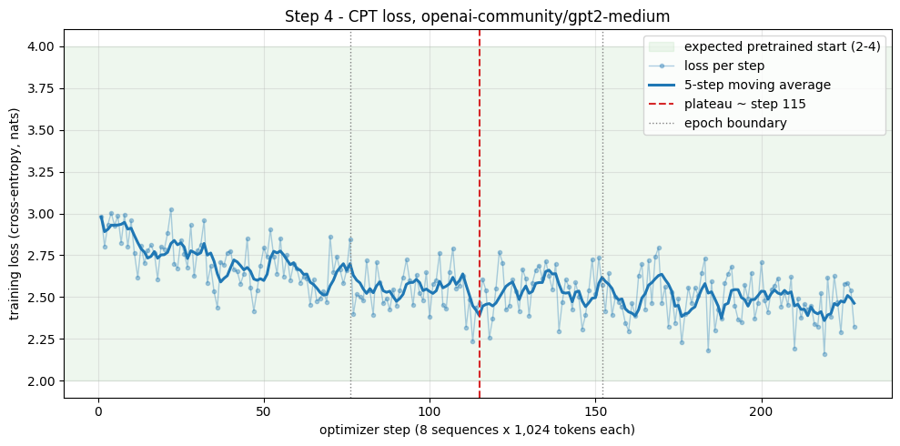

```
========================================
STEP 4 - LOSS ANALYSIS
========================================
measure                            value
----------------------------------------
starting loss (step 1)            2.9790
final loss                        2.3238
lowest loss                       2.1607
smoothed decrease         0.5154 (17.3%)
plateau step                         115
plateau epoch                       1.51
mean loss after plateau           2.5034
logged points                        228
========================================

Loss curve saved to outputs/cpt_loss_curve.png
```

```python
# ---------------------------------------------------------------------------
# Loss curve and plateau detection.
#
# Per-step loss is noisy (each step sees a different 8-sequence batch), so the plateau
# is found on a trailing moving average rather than the raw values. The plateau step is
# defined as the first step by which the smoothed loss has achieved 90% of its total
# decrease: after it, further training buys only the remaining 10%.
# ---------------------------------------------------------------------------
import matplotlib.pyplot as plt

SMOOTH_WINDOW = 5
PLATEAU_SHARE = 0.90


def moving_average(values, window):
    out = []
    for i in range(len(values)):
        chunk = values[max(0, i - window + 1): i + 1]
        out.append(sum(chunk) / len(chunk))
    return out


def find_plateau(steps, smoothed, share=PLATEAU_SHARE):
    """Return (plateau_step, total_drop). plateau_step is None if the loss never fell."""
    start, lowest = smoothed[0], min(smoothed)
    total_drop = start - lowest
    if total_drop <= 0:
        return None, 0.0
    target = start - share * total_drop
    for s, v in zip(steps, smoothed):
        if v <= target:
            return s, total_drop
    return steps[-1], total_drop


steps = [h["step"] for h in loss_history]
losses = [h["loss"] for h in loss_history]
smoothed = moving_average(losses, SMOOTH_WINDOW)
loss_decreased = smoothed[-1] < smoothed[0]
plateau_step, smoothed_drop = find_plateau(steps, smoothed)
if not loss_decreased:
    plateau_step = None    # a curve that ends where it started has no plateau to mark

after_plateau = [l for s, l in zip(steps, losses) if plateau_step is not None and s >= plateau_step]
loss_stats = {
    "start_loss": round(losses[0], 4),
    "final_loss": round(losses[-1], 4),
    "min_loss": round(min(losses), 4),
    "final_smoothed_loss": round(smoothed[-1], 4),
    "smoothed_drop": round(smoothed_drop, 4),
    "relative_drop_pct": round(100 * (smoothed[0] - smoothed[-1]) / smoothed[0], 2),
    "plateau_step": plateau_step,
    "plateau_epoch": next((h["epoch"] for h in loss_history if h["step"] == plateau_step), None),
    "plateau_mean_loss": round(sum(after_plateau) / len(after_plateau), 4) if after_plateau else None,
    "plateau_loss_range": [round(min(after_plateau), 4), round(max(after_plateau), 4)] if after_plateau else None,
    "logged_points": len(losses),
    "smooth_window": SMOOTH_WINDOW,
    "plateau_definition": f"first step where the {SMOOTH_WINDOW}-step moving average "
                          f"achieved {PLATEAU_SHARE:.0%} of its total decrease",
}
fig, ax = plt.subplots(figsize=(10, 5))
ax.axhspan(2, 4, color="tab:green", alpha=0.08, label="expected pretrained start (2-4)")
ax.plot(steps, losses, color="tab:blue", alpha=0.35, linewidth=1, marker=".", label="loss per step")
ax.plot(steps, smoothed, color="tab:blue", linewidth=2.2, label=f"{SMOOTH_WINDOW}-step moving average")
if plateau_step is not None:
    ax.axvline(plateau_step, color="tab:red", linestyle="--", linewidth=1.5,
               label=f"plateau ~ step {plateau_step}")
for e in range(1, CPT_EPOCHS):
    ax.axvline(e * cpt_run["steps_per_epoch"], color="grey", linestyle=":", linewidth=1,
               label="epoch boundary" if e == 1 else None)
ax.set_xlabel(f"optimizer step ({CPT_BATCH_SIZE * CPT_GRAD_ACCUM} sequences x {CONTEXT:,} tokens each)")
ax.set_ylabel("training loss (cross-entropy, nats)")
ax.set_title(f"Step 4 - CPT loss, {MODEL_ID}")
ax.grid(alpha=0.3)
ax.legend(loc="upper right")
fig.tight_layout()

LOSS_FIG_PATH = OUTPUTS_DIR / "cpt_loss_curve.png"
fig.savefig(LOSS_FIG_PATH, dpi=150)
plt.show()

print_table(
    ("measure", "value"),
    [
        ("starting loss (step 1)", f"{loss_stats['start_loss']:.4f}"),
        ("final loss", f"{loss_stats['final_loss']:.4f}"),
        ("lowest loss", f"{loss_stats['min_loss']:.4f}"),
        ("smoothed decrease", f"{smoothed[0] - smoothed[-1]:.4f} ({loss_stats['relative_drop_pct']:.1f}%)"),
        ("plateau step", str(plateau_step) if plateau_step is not None else "none - loss did not fall"),
        ("plateau epoch", f"{loss_stats['plateau_epoch']:.2f}" if loss_stats["plateau_epoch"] is not None else "-"),
        ("mean loss after plateau", f"{loss_stats['plateau_mean_loss']:.4f}" if after_plateau else "-"),
        ("logged points", f"{len(losses)}"),
    ],
    title="STEP 4 - LOSS ANALYSIS",
)
print(f"\nLoss curve saved to {LOSS_FIG_PATH}")
if not loss_decreased:
    print("WARNING: the smoothed loss did not decrease - consider a lower CPT_LR or longer warmup.")
```

```python
# ---------------------------------------------------------------------------
# Save the CPT model and tokenizer to persistent storage (Step 5 and Part B load from here).
# ---------------------------------------------------------------------------
if CPT_SUMMARY_PATH.exists():
    print(f"cpt_ckpt/ already complete at {CPT_CKPT.resolve()} - nothing to save.")
else:
    cpt_model.to(torch.bfloat16)             # one uniform BF16 checkpoint, same dtype as the base
    cpt_model.config.use_cache = True        # restore for generation downstream

    CPT_CKPT.mkdir(parents=True, exist_ok=True)
    cpt_model.save_pretrained(CPT_CKPT, safe_serialization=True)
    tok.save_pretrained(CPT_CKPT)
    (CPT_CKPT / CPT_LOSS_LOG).write_text(json.dumps(loss_history, indent=1), encoding="utf-8")
    shutil.copy(LOSS_FIG_PATH, CPT_CKPT / LOSS_FIG_PATH.name)

    # Written LAST: its presence marks the save as complete.
    CPT_SUMMARY_PATH.write_text(json.dumps({"model_id": MODEL_ID, "run": cpt_run, "loss": loss_stats},
                                           indent=2), encoding="utf-8")
    size_gb = sum(f.stat().st_size for f in CPT_CKPT.rglob("*") if f.is_file()) / 1024**3
    print(f"Saved model + tokenizer to {CPT_CKPT.resolve()} ({size_gb:.2f} GB)")
```

```
Saved model + tokenizer to /content/persistent/cpt_ckpt (0.66 GB)
```

```python
# ---------------------------------------------------------------------------
# Before/after generations: same prompts and greedy settings as Step 3.
# The general prompts are generated now too, because Step 5B compares them.
# ---------------------------------------------------------------------------
if "baseline" not in globals():
    baseline = json.loads(BASELINE_PATH.read_text(encoding="utf-8"))

print("Generating CPT completions ...\n")
cpt_generations = {
    "model_id": MODEL_ID,
    "stage": "after CPT",
    "checkpoint": str(CPT_CKPT),
    "dtype": str(torch.bfloat16),
    "max_new_tokens": MAX_NEW_TOKENS,
    "decoding": "greedy (do_sample=False)",
    "domain": generate_completions(cpt_model, DOMAIN_PROMPTS, "cpt-domain"),
    "general": generate_completions(cpt_model, GENERAL_PROMPTS, "cpt-general"),
}
CPT_GEN_PATH = OUTPUTS_DIR / "cpt_generations.json"
CPT_GEN_PATH.write_text(json.dumps(cpt_generations, indent=2), encoding="utf-8")
print(f"\nSaved to {CPT_GEN_PATH}")

for prompt in DOMAIN_PROMPTS:
    base_cont = baseline["domain"][prompt][len(prompt):].strip()
    cpt_cont = cpt_generations["domain"][prompt][len(prompt):].strip()
    print(f"\n{'=' * 78}\nPROMPT  {prompt}\n{'-' * 78}")
    print(f"  BASE  {base_cont}")
    print(f"  CPT   {cpt_cont}")
```

```
Generating CPT completions ...

  [cpt-domain] The first-line pharmacological treatment for type 2 diabetes is
  [cpt-domain] In adults with type 2 diabetes, the recommended HbA1c target is
  [cpt-domain] Metformin should be used with caution in patients who have
  [cpt-general] The capital of France is
  [cpt-general] Water boils at
  [cpt-general] The speed of light is approximately

Saved to outputs/cpt_generations.json

==============================================================================
PROMPT  The first-line pharmacological treatment for type 2 diabetes is
------------------------------------------------------------------------------
  BASE  metformin, which is a combination of insulin and metformin. Metformin is a hormone that is produced by the pancreas. It is a hormone that is produced by the pancreas that is used to control blood sugar levels. Metformin is a hormone that is produced
  CPT   metformin, which is a combination of metformin and sulphonylureas.
The second-line treatment is metformin plus sulphonylureas.
The third-line treatment is metformin plus metformin.
The fourth-line treatment is metform

==============================================================================
PROMPT  In adults with type 2 diabetes, the recommended HbA1c target is
------------------------------------------------------------------------------
  BASE  6.5% (95% CI, 4.0%-7.0%).

The recommended HbA1c target for adults with type 2 diabetes is 6.5% (95% CI, 4.0%-7.0%).

The recommended HbA1c
  CPT   6.0% (95% CI, 5.0%-7.0%)
(1).
The HbA1c target is a generalisation of the target of 6.0% (95% CI, 5.0%-7.0%) for people with type 2 diabetes

==============================================================================
PROMPT  Metformin should be used with caution in patients who have
------------------------------------------------------------------------------
  BASE  a history of diabetes mellitus, hypertension, or hyperlipidemia.

The use of metformin in patients with diabetes mellitus should be limited to the first 6 months of treatment.

Metformin should be used with caution in patients with a history of hyperlipidemia
  CPT   a history of type 2 diabetes, and in those with a history of cardiovascular disease.

The use of metformin in patients with type 2 diabetes should be considered in the context of a multidisciplinary approach, including a multidisciplinary cardiothoracic surgeon, a cardiologist
```

```python
# Inference - Step 4 (numbers come from this run).
_r, _l = cpt_run, loss_stats
_start_ok = 2 <= _l["start_loss"] <= 4
_peak = (f" Peak GPU memory was **{_r['peak_gpu_memory_gb']:.2f} GB** of the {_r['gpu_total_memory_gb']:.1f} GB on the T4."
         if _r.get("peak_gpu_memory_gb") is not None else "")
_plateau = (
    f"The smoothed loss reaches 90% of its total drop by **step {_l['plateau_step']}** "
    f"(epoch {_l['plateau_epoch']:.2f}). After that the loss stays between "
    f"{_l['plateau_loss_range'][0]:.3f} and {_l['plateau_loss_range'][1]:.3f} "
    f"(mean {_l['plateau_mean_loss']:.3f}), so the later steps only make small changes."
    if _l["plateau_step"] is not None else
    "The smoothed loss did **not** decrease, so no plateau can be identified."
)
_gen_lines = "\n".join(
    f"- **{p}**\n  - base: {baseline['domain'][p][len(p):].strip()}\n"
    f"  - CPT: {cpt_generations['domain'][p][len(p):].strip()}"
    for p in DOMAIN_PROMPTS
)

display(Markdown(f"""**Inference — Step 4**

**Setup.** `{MODEL_ID}` has {_r['total_params']:,} parameters and all {_r['trainable_params']:,} were trained (full-parameter CPT). We used FP32 weights with BF16 autocast (as the brief says for T4), AdamW and gradient checkpointing.{_peak} The data is {_r['train_sequences']} packed sequences of {CONTEXT:,} tokens. Batch {_r['batch_size']} × accumulation {_r['grad_accum']} = {_r['effective_batch_tokens']:,} tokens per step, learning rate {_r['learning_rate']:g} with a cosine schedule and {_r['warmup_steps']} warmup steps, {_r['epochs']} epochs = **{_r['global_step']} optimizer steps**. Loss was logged at every step by the custom `LossLoggerCallback`. We kept the learning rate small and the run short so the model learns the domain without losing its general knowledge, which Step 5B checks.

**Starting loss.** The first loss is **{_l['start_loss']:.3f}**, {"inside" if _start_ok else "outside"} the 2–4 range the brief gives for a pretrained model. A randomly initialised model would start near ln({len(tok):,}) = {math.log(len(tok)):.2f}. {"So the pretrained weights loaded correctly. Clinical guideline text is somewhat out of domain for GPT-2, so CPT has room to improve it." if _start_ok else "This is outside the expected range, so the model loading should be checked."}

**Loss curve and plateau.** The loss goes from {_l['start_loss']:.3f} to {_l['final_loss']:.3f} (lowest {_l['min_loss']:.3f}). The {_l['smooth_window']}-step moving average changed by {-_l['relative_drop_pct']:+.1f}%. {_plateau}

**Checkpoint.** The CPT model and tokenizer are saved to `{CPT_CKPT}` and used in Step 5 and Part B.

**Generations, base vs CPT (same prompts, greedy decoding):**
{_gen_lines}
"""))
```

**Inference — Step 4**

**Setup.** `openai-community/gpt2-medium` has 354,823,168 parameters and all 354,823,168 were trained (full-parameter CPT). We used FP32 weights with BF16 autocast (as the brief says for T4), AdamW and gradient checkpointing. Peak GPU memory was **8.40 GB** of the 14.6 GB on the T4. The data is 607 packed sequences of 1,024 tokens. Batch 4 × accumulation 2 = 8,192 tokens per step, learning rate 2e-05 with a cosine schedule and 23 warmup steps, 3 epochs = **228 optimizer steps**. Loss was logged at every step by the custom `LossLoggerCallback`. We kept the learning rate small and the run short so the model learns the domain without losing its general knowledge, which Step 5B checks.

**Starting loss.** The first loss is **2.979**, inside the 2–4 range the brief gives for a pretrained model. A randomly initialised model would start near ln(50,257) = 10.82. So the pretrained weights loaded correctly. Clinical guideline text is somewhat out of domain for GPT-2, so CPT has room to improve it.

**Loss curve and plateau.** The loss goes from 2.979 to 2.324 (lowest 2.161). The 5-step moving average changed by -17.3%. The smoothed loss reaches 90% of its total drop by **step 115** (epoch 1.51). After that the loss stays between 2.161 and 2.796 (mean 2.503), so the later steps only make small changes.

**Checkpoint.** The CPT model and tokenizer are saved to `persistent/cpt_ckpt` and used in Step 5 and Part B.

**Generations, base vs CPT (same prompts, greedy decoding):**

- **The first-line pharmacological treatment for type 2 diabetes is**

  - base: metformin, which is a combination of insulin and metformin. Metformin is a hormone that is produced by the pancreas. It is a hormone that is produced by the pancreas that is used to control blood sugar levels. Metformin is a hormone that is produced

  - CPT: metformin, which is a combination of metformin and sulphonylureas. The second-line treatment is metformin plus sulphonylureas. The third-line treatment is metformin plus metformin. The fourth-line treatment is metform

- **In adults with type 2 diabetes, the recommended HbA1c target is**

  - base: 6.5% (95% CI, 4.0%-7.0%).

The recommended HbA1c target for adults with type 2 diabetes is 6.5% (95% CI, 4.0%-7.0%).

The recommended HbA1c

- CPT: 6.0% (95% CI, 5.0%-7.0%) (1). The HbA1c target is a generalisation of the target of 6.0% (95% CI, 5.0%-7.0%) for people with type 2 diabetes

- **Metformin should be used with caution in patients who have**

  - base: a history of diabetes mellitus, hypertension, or hyperlipidemia.

The use of metformin in patients with diabetes mellitus should be limited to the first 6 months of treatment.

Metformin should be used with caution in patients with a history of hyperlipidemia

- CPT: a history of type 2 diabetes, and in those with a history of cardiovascular disease.

The use of metformin in patients with type 2 diabetes should be considered in the context of a multidisciplinary approach, including a multidisciplinary cardiothoracic surgeon, a cardiologist

**Observations on the generations — Step 4**

After CPT the model uses more guideline wording. It writes "metformin plus sulphonylureas" and a first/second/third-line list, while the base model calls metformin "a hormone produced by the pancreas". The HbA1c answer also gets a guideline-style citation marker "(1)". But it still only continues the sentence, and it repeats itself and invents details ("third-line treatment is metformin plus metformin", "a multidisciplinary cardiothoracic surgeon"). So CPT improved the style and domain vocabulary, but not the factual reliability.

## Step 5 — Evaluation: Perplexity & Catastrophic Forgetting (2 marks)

**5A.** Perplexity is `exp(total negative log-likelihood / total predicted tokens)`, computed in one `model.eval()` + `torch.no_grad()` loop over the same eval split for the base model and the CPT model. **5B.** The three general-knowledge prompts from Step 3 are compared between the base and CPT models, with a Retained / Degraded verdict per prompt.

```python
# ---------------------------------------------------------------------------
# 5A - Domain perplexity on the held-out split: base model vs CPT model.
#
# One standard cross-entropy evaluation loop, no gradients, no training. Both models see
# exactly the same sequences, and every sequence is CONTEXT tokens with no padding, so
# every position except the first is a predicted token.
#   PPL = exp( total negative log-likelihood / total predicted tokens )
# ---------------------------------------------------------------------------
eval_frame = pd.read_parquet(EVAL_PATH)
eval_seqs = [torch.as_tensor(np.array(ids, dtype=np.int64)) for ids in eval_frame["input_ids"]]
assert all(len(s) == CONTEXT for s in eval_seqs), "eval sequences must all be CONTEXT tokens"
assert max(int(s.max()) for s in eval_seqs) < len(tok), "eval token id outside the vocabulary"


def perplexity(m, seqs):
    """Return (perplexity, mean_nll, predicted_token_count) over seqs."""
    m.eval()
    total_nll, total_tokens = 0.0, 0
    with torch.no_grad():
        for ids in seqs:
            ids = ids.unsqueeze(0).to(m.device)
            logits = m(input_ids=ids).logits[:, :-1, :].float()
            targets = ids[:, 1:]
            nll = torch.nn.functional.cross_entropy(
                logits.reshape(-1, logits.size(-1)), targets.reshape(-1), reduction="sum")
            total_nll += nll.item()
            total_tokens += targets.numel()
    mean_nll = total_nll / total_tokens
    return math.exp(mean_nll), mean_nll, total_tokens


# Free whatever Step 4 left on the GPU before loading two more models, one at a time.
for _name in ("cpt_model", "trainer", "model"):
    globals().pop(_name, None)
free_gpu()

base_eval_model = AutoModelForCausalLM.from_pretrained(MODEL_ID, dtype=torch.bfloat16).to(DEVICE)
ppl_base, nll_base, eval_tokens = perplexity(base_eval_model, eval_seqs)
del base_eval_model
free_gpu()

cpt_eval_model = AutoModelForCausalLM.from_pretrained(CPT_CKPT, dtype=torch.bfloat16).to(DEVICE)
ppl_cpt, nll_cpt, _ = perplexity(cpt_eval_model, eval_seqs)
del cpt_eval_model
free_gpu()

ppl_reduction_pct = (ppl_base - ppl_cpt) / ppl_base * 100

ppl_results = {
    "model_id": MODEL_ID,
    "eval_sequences": len(eval_seqs),
    "eval_tokens_scored": eval_tokens,
    "base_ppl": round(ppl_base, 4),
    "cpt_ppl": round(ppl_cpt, 4),
    "base_mean_nll": round(nll_base, 4),
    "cpt_mean_nll": round(nll_cpt, 4),
    "ppl_reduction_pct": round(ppl_reduction_pct, 2),
    "dtype": "bfloat16",
}
PPL_PATH = OUTPUTS_DIR / "ppl_results.json"
PPL_PATH.write_text(json.dumps(ppl_results, indent=2), encoding="utf-8")

print_table(
    ("measure", "value"),
    [
        ("eval sequences", f"{len(eval_seqs)} x {CONTEXT:,} tokens"),
        ("tokens scored", f"{eval_tokens:,}"),
        ("base model PPL", f"{ppl_base:.3f}"),
        ("CPT model PPL", f"{ppl_cpt:.3f}"),
        ("PPL reduction", f"{ppl_reduction_pct:.2f}%"),
    ],
    title="STEP 5A - DOMAIN PERPLEXITY (same held-out split, no gradients)",
)
print(f"\nSaved to {PPL_PATH}")
print("Brief's expectation: a successful CPT run typically lowers domain PPL by 10-40%.")
```

```
==================================
STEP 5A - DOMAIN PERPLEXITY (same held-out split, no gradients)
==================================
measure                      value
----------------------------------
eval sequences   67 x 1,024 tokens
tokens scored               68,541
base model PPL              14.667
CPT model PPL               11.374
PPL reduction               22.45%
==================================

Saved to outputs/ppl_results.json
Brief's expectation: a successful CPT run typically lowers domain PPL by 10-40%.
```

```python
# ---------------------------------------------------------------------------
# 5B - Catastrophic forgetting: the 3 general prompts, base vs CPT, side by side.
#
# The base outputs come from Step 3 and the CPT outputs from Step 4 (same prompts, same
# greedy decoding), reloaded from their JSON files if the kernel was restarted.
# The verdict is decided by two rules, so it is reproducible rather than eyeballed:
#   - Degraded if the base model gave the expected fact and the CPT model does not, or
#     if the CPT output is degenerate (mostly repeated words) and the base was not.
#   - No change (wrong in both) if neither model gave the expected fact: nothing was lost,
#     but the base model never knew it either.
#   - Retained otherwise.
# ---------------------------------------------------------------------------
if "baseline" not in globals():
    baseline = json.loads(BASELINE_PATH.read_text(encoding="utf-8"))
if "cpt_generations" not in globals():
    cpt_generations = json.loads((OUTPUTS_DIR / "cpt_generations.json").read_text(encoding="utf-8"))

EXPECTED_FACTS = {
    "The capital of France is": ["paris"],
    "Water boils at": ["100", "212"],   # matched as a substring, so "1,000" does not count
    "The speed of light is approximately": ["299", "300,000", "300 000", "3 x 10", "3x10"],   # 186,000 only counts "per second", see has_fact
}


def continuation(full_text, prompt):
    return full_text[len(prompt):].strip()


def has_fact(text, prompt):
    low = text.lower()
    if "186,000" in low and "second" in low:      # miles per second is correct; "per hour" is not
        return True
    return any(fact in low for fact in EXPECTED_FACTS[prompt])


def is_degenerate(text):
    words = text.lower().split()
    return len(words) >= 8 and len(set(words)) / len(words) < 0.35


forgetting_rows = []
for prompt in GENERAL_PROMPTS:
    base_out = continuation(baseline["general"][prompt], prompt)
    cpt_out = continuation(cpt_generations["general"][prompt], prompt)
    base_ok, cpt_ok = has_fact(base_out, prompt), has_fact(cpt_out, prompt)
    degraded = (base_ok and not cpt_ok) or (is_degenerate(cpt_out) and not is_degenerate(base_out))
    forgetting_rows.append({
        "prompt": prompt, "base": base_out, "cpt": cpt_out,
        "base_has_fact": base_ok, "cpt_has_fact": cpt_ok,
        "verdict": "Degraded" if degraded else ("Retained" if (base_ok or cpt_ok) else "No change (wrong in both)"),
    })

lines = ["| Prompt | Base output | CPT output | Verdict |", "|---|---|---|---|"]
for r in forgetting_rows:
    cell = lambda t: t.replace("|", "/").replace("\n", " ")
    lines.append(f"| {r['prompt']} ... | {cell(r['base'])} | {cell(r['cpt'])} | {r['verdict']} |")
FORGETTING_PATH = OUTPUTS_DIR / "forgetting_table.md"
FORGETTING_PATH.write_text("\n".join(lines) + "\n", encoding="utf-8")
display(Markdown("\n".join(lines)))

for r in forgetting_rows:
    print(f"{r['prompt']!r:45} expected fact - base: {r['base_has_fact']}, CPT: {r['cpt_has_fact']}  -> {r['verdict']}")
print(f"\nSaved to {FORGETTING_PATH}")
```

| Prompt | Base output | CPT output | Verdict |
| --- | --- | --- | --- |
| The capital of France is ... | Paris, and the capital of France is Paris. The capital of France is Paris, and the capital of France is Paris. The capital of France is Paris, and the capital of France is Paris. The capital of France… | Paris, the capital of the Republic of France. The capital of the Republic of France is Paris, the capital of the Republic of France. The capital of France is Paris, the capital of the Republic of Fran… | Retained |
| Water boils at ... | a temperature of about 1,000 degrees Fahrenheit. "The water is very hot, and it's very hot," said Dr. David L. Karp, a professor of geology at the University of California, Santa Cruz. "It's very hot,… | a temperature of about 1,000°C. The water is then cooled to -20°C and the temperature is then raised to -20°C. The water is then poured into a glass container and the temperature is raised to -20°C. T… | No change (wrong in both) |
| The speed of light is approximately ... | 186,000 miles per hour. The speed of light is approximately 186,000 miles per hour. The speed of light is approximately 186,000 miles per hour. The speed of light is approximately 186,000 miles per ho… | 186,000 miles per hour. The speed of light is approximately 186,000 miles per hour. The speed of light is approximately 186,000 miles per hour. The speed of light is approximately 186,000 miles per ho… | No change (wrong in both) |

```
'The capital of France is'                    expected fact - base: True, CPT: True  -> Retained
'Water boils at'                              expected fact - base: False, CPT: False  -> No change (wrong in both)
'The speed of light is approximately'         expected fact - base: False, CPT: False  -> No change (wrong in both)

Saved to outputs/forgetting_table.md
```

```python
# Inference - Step 5 (numbers come from the PPL and forgetting results above).
_pr = ppl_results
_n_deg = sum(r["verdict"] == "Degraded" for r in forgetting_rows)
_n_same = sum(r["verdict"].startswith("No change") for r in forgetting_rows)
_red = _pr["ppl_reduction_pct"]
if _red >= 10:
    _ppl_text = (f"a **{_red:.1f}%** drop, "
                 + ("which is inside the 10-40% range the brief calls typical for a successful run."
                    if _red <= 40 else
                    "which is more than the usual 10-40%, so the eval text may be very close to the training text."))
elif _red > 0:
    _ppl_text = f"a **{_red:.1f}%** drop. This is real but below the usual 10-40%, so the run may need more epochs or a higher learning rate."
else:
    _ppl_text = f"a **{_red:.1f}%** change, so there is no improvement and CPT did not adapt the model to this domain."

if _n_deg == 0:
    _forget_text = ("None of the three general prompts got worse after CPT. "
                    + (f"{_n_same} of 3 were already wrong in the base model (small GPT-2 models are weak at plain facts and repeat themselves), "
                       "so these show no loss, but they do not prove a fact was kept. " if _n_same else "")
                    + "The small learning rate and short run adapted the model without clearly erasing what it could already do.")
else:
    _forget_text = (f"{_n_deg} of 3 general prompts got worse. The brief's fix is to cut the learning rate 10x or halve the "
                    "number of steps and run again, which usually keeps most of the domain gain.")
_worth = (
    "On this evidence the trade-off was worth it: domain perplexity fell and general behaviour did not get worse."
    if _red > 0 and _n_deg == 0 else
    "On this evidence the trade-off is questionable and should be revisited before Part B."
)
_rows = "\n".join(
    f"- **{r['prompt']}** - base: {r['base'][:90] or '(empty)'} | CPT: {r['cpt'][:90] or '(empty)'} -> **{r['verdict']}**"
    for r in forgetting_rows
)

display(Markdown(f"""**Inference — Step 5**

**5A, domain perplexity.** On the same {_pr['eval_sequences']} held-out sequences ({_pr['eval_tokens_scored']:,} tokens, never seen in training), the base model scores PPL **{_pr['base_ppl']:.2f}** and the CPT model **{_pr['cpt_ppl']:.2f}**, {_ppl_text} Lower is better, {"so CPT made the model less surprised by guideline text, which means it learned the vocabulary and phrasing of this domain." if _red > 0 else "so this does not confirm domain adaptation."}

One limit: the held-out sequences are random slices of the same documents, so nearby text is shared with training and the drop is probably a bit optimistic. Splitting by whole document would be stricter.

**5B, catastrophic forgetting.**
{_rows}

{_forget_text}

**Was the trade-off worth it?** {_worth}"""))
```

**Inference — Step 5**

**5A, domain perplexity.** On the same 67 held-out sequences (68,541 tokens, never seen in training), the base model scores PPL **14.67** and the CPT model **11.37**, a **22.4%** drop, which is inside the 10-40% range the brief calls typical for a successful run. Lower is better, so CPT made the model less surprised by guideline text, which means it learned the vocabulary and phrasing of this domain.

One limit: the held-out sequences are random slices of the same documents, so nearby text is shared with training and the drop is probably a bit optimistic. Splitting by whole document would be stricter.

**5B, catastrophic forgetting.**

- **The capital of France is** - base: Paris, and the capital of France is Paris.

The capital of France is Paris, and the capita | CPT: Paris, the capital of the Republic of France. The capital of the Republic of France is Par -> **Retained**

- **Water boils at** - base: a temperature of about 1,000 degrees Fahrenheit.

"The water is very hot, and it's very ho | CPT: a temperature of about 1,000°C. The water is then cooled to -20°C and the temperature is t -> **No change (wrong in both)**

- **The speed of light is approximately** - base: 186,000 miles per hour.

The speed of light is approximately 186,000 miles per hour.

The | CPT: 186,000 miles per hour. The speed of light is approximately 186,000 miles per hour. The sp -> **No change (wrong in both)**

None of the three general prompts got worse after CPT. 2 of 3 were already wrong in the base model (small GPT-2 models are weak at plain facts and repeat themselves), so these show no loss, but they do not prove a fact was kept. The small learning rate and short run adapted the model without clearly erasing what it could already do.

**Was the trade-off worth it?** On this evidence the trade-off was worth it: domain perplexity fell and general behaviour did not get worse.

## B1 — Instruction Dataset Creation (2 marks)

**Method (synthetic generation with an external LLM).** We selected 50 passages of about 600–1,100 characters from the cleaned corpus (3–4 per document, 14 documents, seeded random choice). An external LLM (Claude) generated 10 instruction-response pairs per passage with this prompt:

> *Read the text below and generate 10 instruction-response pairs in JSON format based ONLY on this text. Each entry must have `instruction` and `response` keys. Responses must be taken from, or be a faithful short paraphrase of, the text; do not add facts that are not in the passage.* `<passage text>`

The cell below then checks the generated file: every passage must appear in the cleaned corpus, every pair must have a non-empty `instruction` and `response`, and each response must be grounded in its passage (at least 60% of its words appear in the passage). Pairs that fail are dropped and counted.

```python
# ---------------------------------------------------------------------------
# B1 - validate the generated pairs, then shuffle and split 80 / 20.
# ---------------------------------------------------------------------------
import random

SOURCE_PAIRS_PATH = BASE / "instruction_source_pairs.json"
DATASET_PATH = BASE / "instruction_dataset.jsonl"
TRAIN_JSONL = BASE / "instruction_train.jsonl"
EVAL_JSONL = BASE / "instruction_eval.jsonl"
GROUNDING_MIN = 0.60            # share of response words that must occur in the source passage
CORPUS_DIR_B1 = BASE / "domain_corpus"

GENERATION_PROMPT_TEMPLATE = (
    "Read the text below and generate 10 instruction-response pairs in JSON format based ONLY on "
    "this text. Each entry must have instruction and response keys. Responses must be taken from, "
    "or be a faithful short paraphrase of, the text; do not add facts that are not in the passage.\n\n"
    "<passage text>"
)

source_records = json.loads(SOURCE_PAIRS_PATH.read_text(encoding="utf-8"))


def squash(s):
    return re.sub(r"\s+", " ", s).strip()


def words(s):
    return re.findall(r"[a-z0-9]+", s.lower())


corpus_text = {f.name: squash(f.read_text(encoding="utf-8")) for f in CORPUS_DIR_B1.glob("*.txt")}

kept, dropped = [], {"passage not in corpus": 0, "missing/empty key": 0, "not grounded": 0, "duplicate instruction": 0}
seen = set()
for rec in source_records:
    in_corpus = squash(rec["passage"]) in corpus_text.get(rec["source"], "")
    passage_words = set(words(rec["passage"]))
    for pair in rec["pairs"]:
        ins, resp = str(pair.get("instruction", "")).strip(), str(pair.get("response", "")).strip()
        if not in_corpus:
            dropped["passage not in corpus"] += 1
        elif not ins or not resp:
            dropped["missing/empty key"] += 1
        elif sum(w in passage_words for w in words(resp)) / max(len(words(resp)), 1) < GROUNDING_MIN:
            dropped["not grounded"] += 1
        elif (rec["passage_id"], ins.lower()) in seen:
            dropped["duplicate instruction"] += 1
        else:
            seen.add((rec["passage_id"], ins.lower()))
            kept.append({"instruction": ins, "response": resp})

rng = random.Random(SEED)
rng.shuffle(kept)
n_train = int(round(len(kept) * 0.8))
train_pairs, eval_pairs = kept[:n_train], kept[n_train:]


def write_jsonl(path, rows):
    with open(path, "w", encoding="utf-8") as fh:
        for r in rows:
            fh.write(json.dumps(r, ensure_ascii=False) + "\n")


write_jsonl(DATASET_PATH, kept)
write_jsonl(TRAIN_JSONL, train_pairs)
write_jsonl(EVAL_JSONL, eval_pairs)

# Re-read from disk: every line must parse and carry both keys.
for path in (DATASET_PATH, TRAIN_JSONL, EVAL_JSONL):
    for line in open(path, encoding="utf-8"):
        row = json.loads(line)
        assert set(row) == {"instruction", "response"} and row["instruction"] and row["response"]

lengths = [len(words(r["response"])) for r in kept]
print_table(
    ("measure", "value"),
    [
        ("source passages", f"{len(source_records)} from {len({r['source'] for r in source_records})} documents"),
        ("pairs generated", f"{sum(len(r['pairs']) for r in source_records)}"),
        ("pairs dropped by validation", f"{sum(dropped.values())}  {dropped}"),
        ("final pairs (instruction_dataset.jsonl)", f"{len(kept)}"),
        ("train split (80%)", f"{len(train_pairs)}"),
        ("eval split (20%)", f"{len(eval_pairs)}"),
        ("mean response length", f"{sum(lengths) / len(lengths):.1f} words"),
    ],
    title="B1 - INSTRUCTION DATASET",
)
print("\nExample pairs:")
for r in kept[:3]:
    print(f"  Q: {r['instruction']}\n  A: {r['response']}\n")
print("Generation prompt template:\n" + GENERATION_PROMPT_TEMPLATE)
```

```
==================================================================================================================================================
B1 - INSTRUCTION DATASET
==================================================================================================================================================
measure                                                                                                                                      value
--------------------------------------------------------------------------------------------------------------------------------------------------
source passages                                                                                                               50 from 14 documents
pairs generated                                                                                                                                500
pairs dropped by validation               13  {'passage not in corpus': 0, 'missing/empty key': 0, 'not grounded': 13, 'duplicate instruction': 0}
final pairs (instruction_dataset.jsonl)                                                                                                        487
train split (80%)                                                                                                                              390
eval split (20%)                                                                                                                                97
mean response length                                                                                                                    16.9 words
==================================================================================================================================================

Example pairs:
  Q: When else is a 20% dose reduction recommended?
  A: When switching back from once-daily insulin glargine U300 to once-daily insulin glargine U100.

  Q: What is an imperative when formulating IDF guidance?
  A: Recognising the limitations and opportunities presented in the context of varying healthcare systems globally.

  Q: When may metformin be considered in prediabetes?
  A: When lifestyle alone is not sufficient, especially in those with combined IFG and IGT where progression to type 2 diabetes appears imminent, metformin may be considered in addition to lifestyle measures.

Generation prompt template:
Read the text below and generate 10 instruction-response pairs in JSON format based ONLY on this text. Each entry must have instruction and response keys. Responses must be taken from, or be a faithful short paraphrase of, the text; do not add facts that are not in the passage.

<passage text>
```

```python
# ---------------------------------------------------------------------------
# Inference - B1 (numbers come from the counts above).
# ---------------------------------------------------------------------------
_total = sum(len(r["pairs"]) for r in source_records)
display(Markdown(f"""**Inference — B1**

**Size.** {_total} pairs were generated and {len(kept)} passed validation. They are split 80/20 into **{len(train_pairs)} training** and **{len(eval_pairs)} evaluation** pairs. The brief only asks for a suitable size. For a 355M model and a short QLoRA run, a few hundred clean pairs are enough to teach the answer format without overwriting what CPT learned, and more pairs from the same passages would mostly repeat each other.

**Coverage.** The passages come from {len({r['source'] for r in source_records})} different documents (clinical guidelines, quality standards, WHO/IDF reports and statistics reports), so no single source dominates.

**Grounding.** Responses are short and taken from, or closely paraphrased from, the passage. Each response shares at least {GROUNDING_MIN:.0%} of its words with its passage, and every passage was found again in the cleaned corpus. {sum(dropped.values())} pair(s) failed these checks and were dropped. So the answers come from the domain text, as the brief requires, and are not invented.

**Limit of the method.** The pairs were written by an external LLM from the prompt shown above. Pair quality depends on the passage: administrative or methods passages give less useful pairs than guideline recommendations, so we picked passages with clinical content."""))
```

**Inference — B1**

**Size.** 500 pairs were generated and 487 passed validation. They are split 80/20 into **390 training** and **97 evaluation** pairs. The brief only asks for a suitable size. For a 355M model and a short QLoRA run, a few hundred clean pairs are enough to teach the answer format without overwriting what CPT learned, and more pairs from the same passages would mostly repeat each other.

**Coverage.** The passages come from 14 different documents (clinical guidelines, quality standards, WHO/IDF reports and statistics reports), so no single source dominates.

**Grounding.** Responses are short and taken from, or closely paraphrased from, the passage. Each response shares at least 60% of its words with its passage, and every passage was found again in the cleaned corpus. 13 pair(s) failed these checks and were dropped. So the answers come from the domain text, as the brief requires, and are not invented.

**Limit of the method.** The pairs were written by an external LLM from the prompt shown above. Pair quality depends on the passage: administrative or methods passages give less useful pairs than guideline recommendations, so we picked passages with clinical content.

## B2 — QLoRA Fine-Tuning (2 marks)

**Adapter choice: B (balanced), r = 16, alpha = 32.** **Target modules:** the brief's table lists `q_proj` and `v_proj`, but GPT-2 combines query, key and value into one layer called `c_attn`, so Adapter B targets `c_attn`.

**Chat template:** `gpt2-medium` has none, so we set one manually (`Instruction: ... Response: ...` plus the end-of-sequence token) and use it for both training and generation.

```python
# ---------------------------------------------------------------------------
# B2 setup: adapter configuration, the chat template and the formatted training data.
# ---------------------------------------------------------------------------
from datasets import Dataset as HFDataset

ADAPTER_DIR = PERSIST / "adapter"
ADAPTER_R, ADAPTER_ALPHA = 16, 32               # Adapter B (balanced)
ADAPTER_TARGETS = ["c_attn"]                     # GPT-2 fuses q, k and v into this one layer
SFT_EPOCHS, SFT_LR, SFT_BATCH, SFT_ACCUM, SFT_MAX_LEN = 3, 2e-4, 4, 4, 512

# gpt2-medium has no chat template, so we define one. Plain words are used as markers so
# the format does not depend on how a tokenizer treats newlines or symbols.
if tok.pad_token is None:
    tok.pad_token = tok.eos_token      # GPT-2 has no pad token; batched training needs one
tok.chat_template = (
    "{% for m in messages %}"
    "{% if m['role'] == 'user' %}Instruction: {{ m['content'] }} "
    "{% elif m['role'] == 'assistant' %}Response: {{ m['content'] }}{{ eos_token }}"
    "{% endif %}{% endfor %}"
    "{% if add_generation_prompt %}Response: {% endif %}"
)


def load_jsonl(path):
    return [json.loads(line) for line in open(path, encoding="utf-8")]


def to_text(pair):
    return tok.apply_chat_template(
        [{"role": "user", "content": pair["instruction"]},
         {"role": "assistant", "content": pair["response"]}],
        tokenize=False)


train_rows, eval_rows = load_jsonl(TRAIN_JSONL), load_jsonl(EVAL_JSONL)
sft_train = HFDataset.from_list([{"text": to_text(r)} for r in train_rows])
sft_eval = HFDataset.from_list([{"text": to_text(r)} for r in eval_rows])

print(f"Adapter B: r={ADAPTER_R}, alpha={ADAPTER_ALPHA}, targets={ADAPTER_TARGETS}")
print(f"Training examples: {len(sft_train)}   eval examples: {len(sft_eval)}")
print("\nFormatted example:\n" + sft_train[0]["text"])
print("\nGeneration prompt format:\n" + tok.apply_chat_template(
    [{"role": "user", "content": "<question>"}], tokenize=False, add_generation_prompt=True))
```

```
Adapter B: r=16, alpha=32, targets=['c_attn']
Training examples: 390   eval examples: 97

Formatted example:
Instruction: When else is a 20% dose reduction recommended? Response: When switching back from once-daily insulin glargine U300 to once-daily insulin glargine U100.<|endoftext|>

Generation prompt format:
Instruction: <question> Response:
```

```python
import inspect

from peft import LoraConfig, PeftModel, get_peft_model, prepare_model_for_kbit_training
from transformers import BitsAndBytesConfig
from trl import SFTConfig, SFTTrainer

for _name in ("cpt_model", "trainer", "model", "ft_model"):
    globals().pop(_name, None)
free_gpu()

bnb_config = BitsAndBytesConfig(
    load_in_4bit=True,
    bnb_4bit_quant_type="nf4",
    bnb_4bit_compute_dtype=torch.bfloat16,
    bnb_4bit_use_double_quant=True,
)
qlora_base = AutoModelForCausalLM.from_pretrained(CPT_CKPT, quantization_config=bnb_config, device_map={"": 0})
qlora_base.config.use_cache = False
qlora_base = prepare_model_for_kbit_training(qlora_base, use_gradient_checkpointing=True)

lora_config = LoraConfig(r=ADAPTER_R, lora_alpha=ADAPTER_ALPHA, target_modules=ADAPTER_TARGETS,
                         lora_dropout=0.05, bias="none", task_type="CAUSAL_LM")
qlora_model = get_peft_model(qlora_base, lora_config)
qlora_model.print_trainable_parameters()
trainable_lora = sum(p.numel() for p in qlora_model.parameters() if p.requires_grad)
assert trainable_lora > 0, "target_modules matched nothing - check the module names"

# trl renamed a few arguments between releases; pick whichever this install uses.
cfg_params = inspect.signature(SFTConfig).parameters
sft_kwargs = dict(
    output_dir=str(PERSIST / "sft_run"),
    num_train_epochs=SFT_EPOCHS,
    per_device_train_batch_size=SFT_BATCH,
    per_device_eval_batch_size=SFT_BATCH,
    gradient_accumulation_steps=SFT_ACCUM,
    learning_rate=SFT_LR,
    lr_scheduler_type="cosine",
    warmup_steps=4,
    bf16=True,
    gradient_checkpointing=True,
    gradient_checkpointing_kwargs={"use_reentrant": False},
    logging_steps=2,
    save_strategy="no",
    report_to="none",
    seed=SEED,
    dataset_text_field="text",
)



sft_kwargs["max_length" if "max_length" in cfg_params else "max_seq_length"] = SFT_MAX_LEN
sft_kwargs["eval_strategy" if "eval_strategy" in cfg_params else "evaluation_strategy"] = "epoch"

trainer_params = inspect.signature(SFTTrainer.__init__).parameters
tok_kw = {"processing_class": tok} if "processing_class" in trainer_params else {"tokenizer": tok}
sft_trainer = SFTTrainer(model=qlora_model, args=SFTConfig(**sft_kwargs),
                         train_dataset=sft_train, eval_dataset=sft_eval, **tok_kw)

t0 = time.time()
sft_trainer.train()
sft_minutes = (time.time() - t0) / 60

ADAPTER_DIR.mkdir(parents=True, exist_ok=True)
sft_trainer.model.save_pretrained(ADAPTER_DIR)
tok.save_pretrained(ADAPTER_DIR)

history = sft_trainer.state.log_history
train_losses = [h["loss"] for h in history if "loss" in h]
eval_losses = [h["eval_loss"] for h in history if "eval_loss" in h]
sft_summary = {
    "adapter": "B", "r": ADAPTER_R, "alpha": ADAPTER_ALPHA, "target_modules": ADAPTER_TARGETS,
    "epochs": SFT_EPOCHS, "learning_rate": SFT_LR,
    "effective_batch": SFT_BATCH * SFT_ACCUM, "trainable_params": trainable_lora,
    "first_train_loss": train_losses[0], "final_train_loss": train_losses[-1],
    "eval_loss_per_epoch": eval_losses, "train_minutes": round(sft_minutes, 1),
}
(ADAPTER_DIR / "sft_summary.json").write_text(json.dumps(sft_summary, indent=2), encoding="utf-8")

print_table(
    ("measure", "value"),
    [
        ("adapter", f"B: r={ADAPTER_R}, alpha={ADAPTER_ALPHA}, {ADAPTER_TARGETS}"),
        ("trainable parameters", f"{trainable_lora:,}"),
        ("epochs / effective batch", f"{SFT_EPOCHS} / {SFT_BATCH * SFT_ACCUM}"),
        ("first logged train loss", f"{train_losses[0]:.4f}"),
        ("final logged train loss", f"{train_losses[-1]:.4f}"),
        ("eval loss per epoch", ", ".join(f"{x:.4f}" for x in eval_losses)),
        ("training time", f"{sft_minutes:.1f} min"),
    ],
    title="B2 - QLORA TRAINING",
)
print(f"\nAdapter saved to {ADAPTER_DIR.resolve()}")
```

```
trainable params: 1,572,864 || all params: 356,396,032 || trainable%: 0.4413
```

[75/75 01:49, Epoch 3/3]

| Epoch | Training Loss | Validation Loss | Entropy | Num Tokens | Mean Token Accuracy |
| --- | --- | --- | --- | --- | --- |
| 1 | 3.033800 | 2.859424 | 3.122238 | 15231.000000 | 0.453669 |
| 2 | 2.866186 | 2.551243 | 2.552373 | 30462.000000 | 0.517065 |
| 3 | 2.582031 | 2.536226 | 2.537093 | 45693.000000 | 0.518976 |

```
========================================================
B2 - QLORA TRAINING
========================================================
measure                                            value
--------------------------------------------------------
adapter                    B: r=16, alpha=32, ['c_attn']
trainable parameters                           1,572,864
epochs / effective batch                          3 / 16
first logged train loss                           3.8207
final logged train loss                           2.5820
eval loss per epoch               2.8594, 2.5512, 2.5362
training time                                    1.8 min
========================================================

Adapter saved to /content/persistent/adapter
```

```python
# ---------------------------------------------------------------------------
# B2 smoke test and inference: load the saved adapter onto a fresh copy of cpt_ckpt/ and
# generate. This also builds `ft_model`, which B3 reuses.
# ---------------------------------------------------------------------------
for _name in ("sft_trainer", "qlora_model", "qlora_base"):
    globals().pop(_name, None)
free_gpu()

fresh_base = AutoModelForCausalLM.from_pretrained(CPT_CKPT, quantization_config=bnb_config, device_map={"": 0})
ft_model = PeftModel.from_pretrained(fresh_base, ADAPTER_DIR)
ft_model.eval()

SFT_MAX_NEW_TOKENS = 80


def generate_instruct(m, instructions, tag):
    """Greedy answers through the chat template. Returns {instruction: answer}."""
    out = {}
    for ins in instructions:
        prompt = tok.apply_chat_template([{"role": "user", "content": ins}], tokenize=False,
                                         add_generation_prompt=True)
        prompt = prompt.rstrip()   # no trailing space: the answer's first token carries its own
        ids = tok(prompt, return_tensors="pt").to(m.device)
        with torch.no_grad():
            gen = m.generate(**ids, max_new_tokens=SFT_MAX_NEW_TOKENS, do_sample=False, no_repeat_ngram_size=4,
                             pad_token_id=tok.pad_token_id if tok.pad_token_id is not None else eos_id)
        answer = tok.decode(gen[0][ids["input_ids"].shape[1]:], skip_special_tokens=True)
        answer = answer.split("Instruction:")[0]             # stop if the model starts a new turn
        if "Response:" in answer:                            # a sentence-stem prompt can be echoed first
            answer = answer.split("Response:")[1]            # keep the answer after the first marker
        out[ins] = answer.strip()
        print(f"  [{tag}] {ins}")
    return out


smoke_questions = [r["instruction"] for r in eval_rows[:3]]
smoke = generate_instruct(ft_model, smoke_questions, "smoke")
for q, a in zip(smoke_questions, smoke.values()):
    reference = next(r["response"] for r in eval_rows if r["instruction"] == q)
    print(f"\nQ: {q}\nADAPTER: {a}\nREFERENCE: {reference}")
assert all(sum(ch.isalpha() for ch in a) >= 10 for a in smoke.values()), \
    "adapter output is empty or not text - check the generation prompt format"

_s = sft_summary
display(Markdown(f"""**Inference — B2**

**Configuration.** Adapter **B** (r = {_s['r']}, alpha = {_s['alpha']}, `{', '.join(_s['target_modules'])}`) was trained on {len(sft_train)} pairs for {_s['epochs']} epochs with learning rate {_s['learning_rate']:g} (effective batch {_s['effective_batch']}). Adapter A has less capacity and may underfit domain questions. Adapter C also adds the attention output projection, which costs more VRAM and time than {len(sft_train)} short pairs need. QLoRA keeps the CPT weights frozen and trains only {_s['trainable_params']:,} adapter parameters, so the domain knowledge from CPT is kept while the adapter learns the instruction-response format. The model is loaded from `cpt_ckpt/` and not from the original base, so Part B builds on Part A.

**Chat template.** `gpt2-medium` has no chat template, so we defined `Instruction: ... Response: ...` followed by the end-of-sequence token and used it for both training and generation. Plain words are used as markers so the format does not depend on how the tokenizer treats symbols. GPT-2 combines q, k and v in one `c_attn` layer, which is why the target is `c_attn` and not the brief's `q_proj`/`v_proj`.

**Training loss.** Training loss went from {_s['first_train_loss']:.3f} to {_s['final_train_loss']:.3f}. Evaluation loss per epoch was {", ".join(f"{x:.3f}" for x in _s['eval_loss_per_epoch'])}. {"The eval loss fell, so the adapter generalises to held-out pairs." if len(_s['eval_loss_per_epoch']) > 1 and _s['eval_loss_per_epoch'][-1] <= _s['eval_loss_per_epoch'][0] else "The eval loss did not fall, so the adapter may be overfitting or underfitting."}

**Smoke test.** The saved adapter loaded onto a fresh copy of `cpt_ckpt/` and produced a readable answer for held-out questions. The answers are often not factually right (see the reference answers above), which is expected for a small model with little training data."""))
```

```
  [smoke] How does HHS differ from diabetic ketoacidosis in terms of ketones?
  [smoke] Which SIGN guideline covers obesity management?
  [smoke] Summarise the WHO statement on national capacity for diabetes control.

Q: How does HHS differ from diabetic ketoacidosis in terms of ketones?
ADAPTER: HHS does not have a specific definition of diabetes. The definition is based on the presence of a glucose-lowering agent, and the presence of an insulin-like peptide-1 receptor agonist.
REFERENCE: In HHS little substrate is available for ketoacids, so metabolic acidosis does not occur.

Q: Which SIGN guideline covers obesity management?
ADAPTER: The National Institute for Health and Care Excellence (NICE) guideline on the management of overweight and obesity.
REFERENCE: SIGN 115, the guideline on the management of obesity.

Q: Summarise the WHO statement on national capacity for diabetes control.
ADAPTER: The statement is based on the WHO Global Strategy for Diabetes Control, which was developed in collaboration with the WHO Global Health Response and the WHO Global Action Plan on Diabetes.
REFERENCE: Capacity should be improved through integrated NCD management, at least combining diabetes and cardiovascular care; national capacity varies widely, and although most countries have diabetes policies and guidelines, in some regions and lower-income countries they lack funding and implemen…
```

**Inference — B2**

**Configuration.** Adapter **B** (r = 16, alpha = 32, `c_attn`) was trained on 390 pairs for 3 epochs with learning rate 0.0002 (effective batch 16). Adapter A has less capacity and may underfit domain questions. Adapter C also adds the attention output projection, which costs more VRAM and time than 390 short pairs need. QLoRA keeps the CPT weights frozen and trains only 1,572,864 adapter parameters, so the domain knowledge from CPT is kept while the adapter learns the instruction-response format. The model is loaded from `cpt_ckpt/` and not from the original base, so Part B builds on Part A.

**Chat template.** `gpt2-medium` has no chat template, so we defined `Instruction: ... Response: ...` followed by the end-of-sequence token and used it for both training and generation. Plain words are used as markers so the format does not depend on how the tokenizer treats symbols. GPT-2 combines q, k and v in one `c_attn` layer, which is why the target is `c_attn` and not the brief's `q_proj`/`v_proj`.

**Training loss.** Training loss went from 3.821 to 2.582. Evaluation loss per epoch was 2.859, 2.551, 2.536. The eval loss fell, so the adapter generalises to held-out pairs.

**Smoke test.** The saved adapter loaded onto a fresh copy of `cpt_ckpt/` and produced a readable answer for held-out questions. The answers are often not factually right (see the reference answers above), which is expected for a small model with little training data.

## B3 — Evaluation Analysis (1 mark)

The same three domain prompts from Steps 3 and 4 are run through the adapter model (given as the instruction in the chat template) and shown next to the base and CPT outputs.

```python
# ---------------------------------------------------------------------------
# B3 - the same 3 domain prompts through base, CPT and CPT + adapter.
# ---------------------------------------------------------------------------
if "baseline" not in globals():
    baseline = json.loads(BASELINE_PATH.read_text(encoding="utf-8"))
if "cpt_generations" not in globals():
    cpt_generations = json.loads((OUTPUTS_DIR / "cpt_generations.json").read_text(encoding="utf-8"))

print("Generating adapter outputs ...\n")
adapter_generations = {
    "model_id": MODEL_ID, "stage": "CPT + QLoRA adapter B",
    "max_new_tokens": SFT_MAX_NEW_TOKENS, "decoding": "greedy (do_sample=False)",
    "domain": generate_instruct(ft_model, DOMAIN_PROMPTS, "adapter-domain"),
}
ADAPTER_GEN_PATH = OUTPUTS_DIR / "adapter_generations.json"
ADAPTER_GEN_PATH.write_text(json.dumps(adapter_generations, indent=2), encoding="utf-8")

b3_rows = []
for p in DOMAIN_PROMPTS:
    b3_rows.append({
        "prompt": p,
        "base": continuation(baseline["domain"][p], p),
        "cpt": continuation(cpt_generations["domain"][p], p),
        "adapter": adapter_generations["domain"][p],
    })

cell_b3 = lambda t: t.replace("|", "/").replace("\n", " ")
table_b3 = ["| Prompt | Base (Step 3) | CPT (Step 4) | CPT + adapter (B2) |", "|---|---|---|---|"]
for r in b3_rows:
    table_b3.append(f"| {r['prompt']} ... | {cell_b3(r['base'])} | {cell_b3(r['cpt'])} | {cell_b3(r['adapter'])} |")
display(Markdown("\n".join(table_b3)))
print(f"\nSaved to {ADAPTER_GEN_PATH}")
```

```
Generating adapter outputs ...

  [adapter-domain] The first-line pharmacological treatment for type 2 diabetes is
  [adapter-domain] In adults with type 2 diabetes, the recommended HbA1c target is
  [adapter-domain] Metformin should be used with caution in patients who have
```

| Prompt | Base (Step 3) | CPT (Step 4) | CPT + adapter (B2) |
| --- | --- | --- | --- |
| The first-line pharmacological treatment for type 2 diabetes is ... | metformin, which is a combination of insulin and metformin. Metformin is a hormone that is produced by the pancreas. It is a hormone that is produced by the pancreas that is used to control blood suga… | metformin, which is a combination of metformin and sulphonylureas. The second-line treatment is metformin plus sulphonylureas. The third-line treatment is metformin plus metformin. The fourth-line tre… | Insulin is the first-line treatment for type 1 diabetes. |
| In adults with type 2 diabetes, the recommended HbA1c target is ... | 6.5% (95% CI, 4.0%-7.0%). The recommended HbA1c target for adults with type 2 diabetes is 6.5% (95% CI, 4.0%-7.0%). The recommended HbA1c | 6.0% (95% CI, 5.0%-7.0%) (1). The HbA1c target is a generalisation of the target of 6.0% (95% CI, 5.0%-7.0%) for people with type 2 diabetes | 6-7%. |
| Metformin should be used with caution in patients who have ... | a history of diabetes mellitus, hypertension, or hyperlipidemia. The use of metformin in patients with diabetes mellitus should be limited to the first 6 months of treatment. Metformin should be used … | a history of type 2 diabetes, and in those with a history of cardiovascular disease. The use of metformin in patients with type 2 diabetes should be considered in the context of a multidisciplinary ap… | No response. |

```
Saved to outputs/adapter_generations.json
```

**Observations — B3**

The base model rambles and repeats, and gets facts wrong ("metformin ... is a hormone"). The CPT model uses more guideline wording but still only continues the sentence, with repetition. The adapter changes the behaviour: it gives a short, complete answer ("6-7%.") instead of running on. But its facts are weak: it answers "Insulin is the first-line treatment for type 1 diabetes" for a type 2 prompt, and "No response." for the metformin prompt. Part of the reason is a format mismatch: our three prompts are sentence stems, but the adapter was trained on question-style instructions, so it treats them as a question to answer instead of a sentence to finish. With only 390 pairs and 3 epochs on a 355M model, the adapter learns the answer format much better than the facts.